# Overview

Dataset info

| Number of variables | 79 |
| --- | --- |
| Number of observations | 10000 |
| Total Missing (%) | 0.0% |
| Total size in memory | 6.0 MiB |
| Average record size in memory | 632.0 B |

Variables types

| Numeric | 44 |
| --- | --- |
| Categorical | 7 |
| Boolean | 24 |
| Date | 0 |
| Text (Unique) | 0 |
| Rejected | 4 |
| Unsupported | 0 |

Warnings

- `AP_PELIG` is highly correlated with `PR_PELIG` (ρ = 0.94088) Rejected
- `BOOKBUYERI` has 990 / 9.9% zeros Zeros
- `COMM_609P` has 270 / 2.7% zeros Zeros
- `COMM_CP` has 102 / 1.0% zeros Zeros
- `COMM_PT` has 2463 / 24.6% zeros Zeros
- `COMM_WALK` has 4718 / 47.2% zeros Zeros
- `CULINARYIN` has 9860 / 98.6% zeros Zeros
- `DOITYOURSE` has 9740 / 97.4% zeros Zeros
- `E_PELIG` has 1886 / 18.9% zeros Zeros
- `FAMILYMAGA` has 4167 / 41.7% zeros Zeros
- `FEMALEORIE` has 9862 / 98.6% zeros Zeros
- `FINANCIALM` has 8770 / 87.7% zeros Zeros
- `GARDENINGM` has 9836 / 98.4% zeros Zeros
- `G_PELIG` has 1903 / 19.0% zeros Zeros
- `HEALTHFITN` has 1185 / 11.8% zeros Zeros
- `HH_ND` has 3687 / 36.9% zeros Zeros
- `HH_NI` has 5851 / 58.5% zeros Zeros
- `HH_NR` has 5694 / 56.9% zeros Zeros
- `HISP` has 970 / 9.7% zeros Zeros
- `NH_AA` has 269 / 2.7% zeros Zeros
- `NH_ASIAN` has 2320 / 23.2% zeros Zeros
- `NH_MULT` has 2373 / 23.7% zeros Zeros
- `NL2PP` is highly correlated with `PP_PELIG` (ρ = 0.99193) Rejected
- `NL3PR` is highly correlated with `AP_PELIG` (ρ = 0.91199) Rejected
- `NL5AP` is highly correlated with `NL3PR` (ρ = 0.94158) Rejected
- `NL5G` has 1903 / 19.0% zeros Zeros
- `OPP_SEX` has 9853 / 98.5% zeros Zeros
- `POLITICALC` has 4743 / 47.4% zeros Zeros
- `PP_PELIG` has 7602 / 76.0% zeros Zeros
- `PR_PELIG` has 7371 / 73.7% zeros Zeros
- `REG_DAYS` has 1354 / 13.5% zeros Zeros
- `RELIGIOUSC` has 4754 / 47.5% zeros Zeros
- `UPSCALEBUY` has 9945 / 99.5% zeros Zeros
- `UPSCALEFEM` has 7477 / 74.8% zeros Zeros
- `UPSCALEMAL` has 9866 / 98.7% zeros Zeros

# Variables

AGE  
Numeric

| Distinct count | 82 |
| --- | --- |
| Unique (%) | 0.8% |
| Missing (%) | 0.0% |
| Missing (n) | 0 |
| Infinite (%) | 0.0% |
| Infinite (n) | 0 |

| Mean | 50.87 |
| --- | --- |
| Minimum | 18 |
| Maximum | 100 |
| Zeros (%) | 0.0% |

Toggle details

**Statistics**

Quantile statistics

| Minimum | 18 |
| --- | --- |
| 5-th percentile | 22 |
| Q1 | 36 |
| Median | 51 |
| Q3 | 64 |
| 95-th percentile | 81 |
| Maximum | 100 |
| Range | 82 |
| Interquartile range | 28 |

Descriptive statistics

| Standard deviation | 18.152 |
| --- | --- |
| Coef of variation | 0.35682 |
| Kurtosis | -0.79463 |
| Mean | 50.87 |
| MAD | 15.152 |
| Skewness | 0.11523 |
| Sum | 508697 |
| Variance | 329.48 |
| Memory size | 78.2 KiB |

**Histogram**

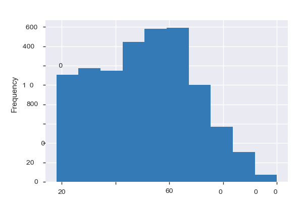

**Common Values**

| Value | Count | Frequency (%) |  |
| --- | --- | --- | --- |
| 52 | 228 | 2.3% |  |
| 53 | 211 | 2.1% |  |
| 54 | 209 | 2.1% |  |
| 67 | 207 | 2.1% |  |
| 58 | 202 | 2.0% |  |
| 57 | 202 | 2.0% |  |
| 50 | 202 | 2.0% |  |
| 59 | 200 | 2.0% |  |
| 43 | 193 | 1.9% |  |
| 56 | 191 | 1.9% |  |
| Other values (72) | 7955 | 79.5% |  |

**Extreme Values**

Minimum 5 values

| Value | Count | Frequency (%) |  |
| --- | --- | --- | --- |
| 18 | 113 | 1.1% |  |
| 19 | 51 | 0.5% |  |
| 20 | 108 | 1.1% |  |
| 21 | 118 | 1.2% |  |
| 22 | 127 | 1.3% |  |

Maximum 5 values

| Value | Count | Frequency (%) |  |
| --- | --- | --- | --- |
| 95 | 8 | 0.1% |  |
| 96 | 8 | 0.1% |  |
| 97 | 2 | 0.0% |  |
| 98 | 3 | 0.0% |  |
| 100 | 4 | 0.0% |  |

AP_PELIG  
Highly correlated

*This variable is highly correlated with `PR_PELIG` and should be ignored for analysis*

| Correlation | 0.94088 |
| --- | --- |

BOOKBUYERI  
Numeric

| Distinct count | 10 |
| --- | --- |
| Unique (%) | 0.1% |
| Missing (%) | 0.0% |
| Missing (n) | 0 |
| Infinite (%) | 0.0% |
| Infinite (n) | 0 |

| Mean | 1.4557 |
| --- | --- |
| Minimum | 0 |
| Maximum | 9 |
| Zeros (%) | 9.9% |

Toggle details

**Statistics**

Quantile statistics

| Minimum | 0 |
| --- | --- |
| 5-th percentile | 0 |
| Q1 | 1 |
| Median | 1 |
| Q3 | 2 |
| 95-th percentile | 2 |
| Maximum | 9 |
| Range | 9 |
| Interquartile range | 1 |

Descriptive statistics

| Standard deviation | 0.96588 |
| --- | --- |
| Coef of variation | 0.66352 |
| Kurtosis | 17.883 |
| Mean | 1.4557 |
| MAD | 0.68897 |
| Skewness | 2.8189 |
| Sum | 14557 |
| Variance | 0.93293 |
| Memory size | 78.2 KiB |

**Histogram**

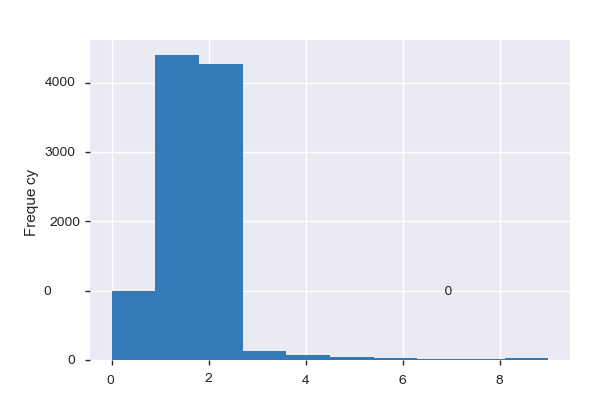

**Common Values**

| Value | Count | Frequency (%) |  |
| --- | --- | --- | --- |
| 1 | 4397 | 44.0% |  |
| 2 | 4277 | 42.8% |  |
| 0 | 990 | 9.9% |  |
| 3 | 127 | 1.3% |  |
| 4 | 70 | 0.7% |  |
| 5 | 39 | 0.4% |  |
| 6 | 32 | 0.3% |  |
| 9 | 31 | 0.3% |  |
| 8 | 20 | 0.2% |  |
| 7 | 17 | 0.2% |  |

**Extreme Values**

Minimum 5 values

| Value | Count | Frequency (%) |  |
| --- | --- | --- | --- |
| 0 | 990 | 9.9% |  |
| 1 | 4397 | 44.0% |  |
| 2 | 4277 | 42.8% |  |
| 3 | 127 | 1.3% |  |
| 4 | 70 | 0.7% |  |

Maximum 5 values

| Value | Count | Frequency (%) |  |
| --- | --- | --- | --- |
| 5 | 39 | 0.4% |  |
| 6 | 32 | 0.3% |  |
| 7 | 17 | 0.2% |  |
| 8 | 20 | 0.2% |  |
| 9 | 31 | 0.3% |  |

CAND1S  
Categorical

| Distinct count | 3 |
| --- | --- |
| Unique (%) | 0.0% |
| Missing (%) | 0.0% |
| Missing (n) | 0 |

| S | 5379 |
| --- | --- |
| U | 2393 |
| L | 2228 |

Toggle details

| Value | Count | Frequency (%) |  |
| --- | --- | --- | --- |
| S | 5379 | 53.8% |  |
| U | 2393 | 23.9% |  |
| L | 2228 | 22.3% |  |

CAND1_UND  
Categorical

| Distinct count | 2 |
| --- | --- |
| Unique (%) | 0.0% |
| Missing (%) | 0.0% |
| Missing (n) | 0 |

| N | 7607 |
| --- | --- |
| Y | 2393 |

Toggle details

| Value | Count | Frequency (%) |  |
| --- | --- | --- | --- |
| N | 7607 | 76.1% |  |
| Y | 2393 | 23.9% |  |

CAND2S  
Categorical

| Distinct count | 3 |
| --- | --- |
| Unique (%) | 0.0% |
| Missing (%) | 0.0% |
| Missing (n) | 0 |

| S | 7968 |
| --- | --- |
| L | 1361 |
| U | 671 |

Toggle details

| Value | Count | Frequency (%) |  |
| --- | --- | --- | --- |
| S | 7968 | 79.7% |  |
| L | 1361 | 13.6% |  |
| U | 671 | 6.7% |  |

CAND2_UND  
Categorical

| Distinct count | 2 |
| --- | --- |
| Unique (%) | 0.0% |
| Missing (%) | 0.0% |
| Missing (n) | 0 |

| N | 9329 |
| --- | --- |
| Y | 671 |

Toggle details

| Value | Count | Frequency (%) |  |
| --- | --- | --- | --- |
| N | 9329 | 93.3% |  |
| Y | 671 | 6.7% |  |

COMM_609P  
Numeric

| Distinct count | 17 |
| --- | --- |
| Unique (%) | 0.2% |
| Missing (%) | 0.0% |
| Missing (n) | 0 |
| Infinite (%) | 0.0% |
| Infinite (n) | 0 |

| Mean | 7.5587 |
| --- | --- |
| Minimum | 0 |
| Maximum | 20 |
| Zeros (%) | 2.7% |

Toggle details

**Statistics**

Quantile statistics

| Minimum | 0 |
| --- | --- |
| 5-th percentile | 1 |
| Q1 | 4 |
| Median | 6 |
| Q3 | 10 |
| 95-th percentile | 18 |
| Maximum | 20 |
| Range | 20 |
| Interquartile range | 6 |

Descriptive statistics

| Standard deviation | 4.9238 |
| --- | --- |
| Coef of variation | 0.65141 |
| Kurtosis | 0.10065 |
| Mean | 7.5587 |
| MAD | 3.8925 |
| Skewness | 0.88778 |
| Sum | 75587 |
| Variance | 24.244 |
| Memory size | 78.2 KiB |

**Histogram**

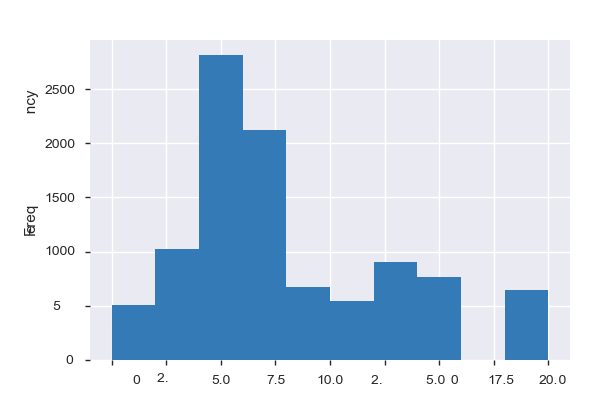

**Common Values**

| Value | Count | Frequency (%) |  |
| --- | --- | --- | --- |
| 5 | 1754 | 17.5% |  |
| 7 | 1435 | 14.3% |  |
| 4 | 1059 | 10.6% |  |
| 2 | 1029 | 10.3% |  |
| 15 | 709 | 7.1% |  |
| 6 | 686 | 6.9% |  |
| 8 | 591 | 5.9% |  |
| 10 | 541 | 5.4% |  |
| 13 | 521 | 5.2% |  |
| 20 | 419 | 4.2% |  |
| Other values (7) | 1256 | 12.6% |  |

**Extreme Values**

Minimum 5 values

| Value | Count | Frequency (%) |  |
| --- | --- | --- | --- |
| 0 | 270 | 2.7% |  |
| 1 | 240 | 2.4% |  |
| 2 | 1029 | 10.3% |  |
| 4 | 1059 | 10.6% |  |
| 5 | 1754 | 17.5% |  |

Maximum 5 values

| Value | Count | Frequency (%) |  |
| --- | --- | --- | --- |
| 14 | 54 | 0.5% |  |
| 15 | 709 | 7.1% |  |
| 17 | 1 | 0.0% |  |
| 18 | 229 | 2.3% |  |
| 20 | 419 | 4.2% |  |

COMM_CAR  
Numeric

| Distinct count | 28 |
| --- | --- |
| Unique (%) | 0.3% |
| Missing (%) | 0.0% |
| Missing (n) | 0 |
| Infinite (%) | 0.0% |
| Infinite (n) | 0 |

| Mean | 80.371 |
| --- | --- |
| Minimum | 36 |
| Maximum | 100 |
| Zeros (%) | 0.0% |

Toggle details

**Statistics**

Quantile statistics

| Minimum | 36 |
| --- | --- |
| 5-th percentile | 62 |
| Q1 | 76 |
| Median | 83 |
| Q3 | 87 |
| 95-th percentile | 92 |
| Maximum | 100 |
| Range | 64 |
| Interquartile range | 11 |

Descriptive statistics

| Standard deviation | 9.936 |
| --- | --- |
| Coef of variation | 0.12363 |
| Kurtosis | 4.8124 |
| Mean | 80.371 |
| MAD | 7.4114 |
| Skewness | -1.712 |
| Sum | 803707 |
| Variance | 98.725 |
| Memory size | 78.2 KiB |

**Histogram**

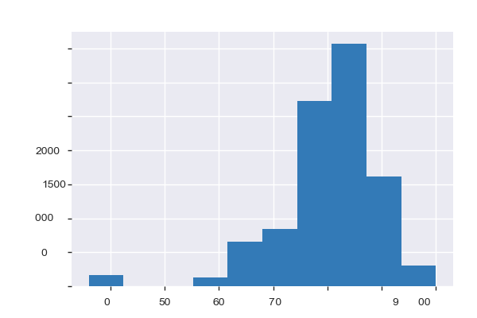

**Common Values**

| Value | Count | Frequency (%) |  |
| --- | --- | --- | --- |
| 76 | 1169 | 11.7% |  |
| 86 | 1020 | 10.2% |  |
| 78 | 1004 | 10.0% |  |
| 84 | 866 | 8.7% |  |
| 87 | 841 | 8.4% |  |
| 92 | 563 | 5.6% |  |
| 88 | 545 | 5.5% |  |
| 90 | 506 | 5.1% |  |
| 62 | 412 | 4.1% |  |
| 85 | 335 | 3.4% |  |
| Other values (18) | 2739 | 27.4% |  |

**Extreme Values**

Minimum 5 values

| Value | Count | Frequency (%) |  |
| --- | --- | --- | --- |
| 36 | 161 | 1.6% |  |
| 57 | 131 | 1.3% |  |
| 62 | 412 | 4.1% |  |
| 66 | 238 | 2.4% |  |
| 69 | 285 | 2.9% |  |

Maximum 5 values

| Value | Count | Frequency (%) |  |
| --- | --- | --- | --- |
| 92 | 563 | 5.6% |  |
| 94 | 142 | 1.4% |  |
| 95 | 59 | 0.6% |  |
| 96 | 101 | 1.0% |  |
| 100 | 1 | 0.0% |  |

COMM_CP  
Numeric

| Distinct count | 21 |
| --- | --- |
| Unique (%) | 0.2% |
| Missing (%) | 0.0% |
| Missing (n) | 0 |
| Infinite (%) | 0.0% |
| Infinite (n) | 0 |

| Mean | 9.1016 |
| --- | --- |
| Minimum | 0 |
| Maximum | 36 |
| Zeros (%) | 1.0% |

Toggle details

**Statistics**

Quantile statistics

| Minimum | 0 |
| --- | --- |
| 5-th percentile | 1 |
| Q1 | 6 |
| Median | 8 |
| Q3 | 11 |
| 95-th percentile | 21 |
| Maximum | 36 |
| Range | 36 |
| Interquartile range | 5 |

Descriptive statistics

| Standard deviation | 5.7228 |
| --- | --- |
| Coef of variation | 0.62877 |
| Kurtosis | 5.1872 |
| Mean | 9.1016 |
| MAD | 4.0433 |
| Skewness | 1.7732 |
| Sum | 91016 |
| Variance | 32.75 |
| Memory size | 78.2 KiB |

**Histogram**

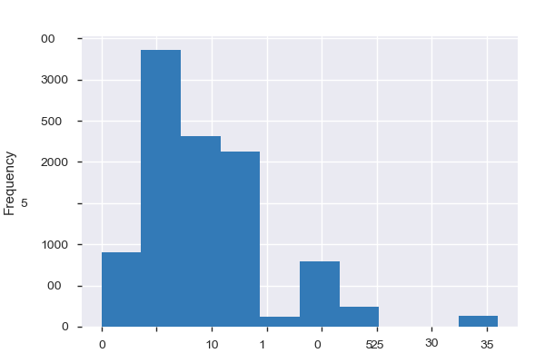

**Common Values**

| Value | Count | Frequency (%) |  |
| --- | --- | --- | --- |
| 6 | 1801 | 18.0% |  |
| 8 | 1462 | 14.6% |  |
| 11 | 1357 | 13.6% |  |
| 5 | 850 | 8.5% |  |
| 12 | 753 | 7.5% |  |
| 9 | 638 | 6.4% |  |
| 1 | 417 | 4.2% |  |
| 7 | 387 | 3.9% |  |
| 18 | 368 | 3.7% |  |
| 2 | 354 | 3.5% |  |
| Other values (11) | 1613 | 16.1% |  |

**Extreme Values**

Minimum 5 values

| Value | Count | Frequency (%) |  |
| --- | --- | --- | --- |
| 0 | 102 | 1.0% |  |
| 1 | 417 | 4.2% |  |
| 2 | 354 | 3.5% |  |
| 3 | 34 | 0.3% |  |
| 4 | 319 | 3.2% |  |

Maximum 5 values

| Value | Count | Frequency (%) |  |
| --- | --- | --- | --- |
| 19 | 269 | 2.7% |  |
| 21 | 160 | 1.6% |  |
| 22 | 221 | 2.2% |  |
| 23 | 18 | 0.2% |  |
| 36 | 131 | 1.3% |  |

COMM_LT10  
Numeric

| Distinct count | 26 |
| --- | --- |
| Unique (%) | 0.3% |
| Missing (%) | 0.0% |
| Missing (n) | 0 |
| Infinite (%) | 0.0% |
| Infinite (n) | 0 |

| Mean | 12.952 |
| --- | --- |
| Minimum | 1 |
| Maximum | 35 |
| Zeros (%) | 0.0% |

Toggle details

**Statistics**

Quantile statistics

| Minimum | 1 |
| --- | --- |
| 5-th percentile | 3 |
| Q1 | 7 |
| Median | 11 |
| Q3 | 17 |
| 95-th percentile | 27 |
| Maximum | 35 |
| Range | 34 |
| Interquartile range | 10 |

Descriptive statistics

| Standard deviation | 8.1434 |
| --- | --- |
| Coef of variation | 0.62874 |
| Kurtosis | 0.2916 |
| Mean | 12.952 |
| MAD | 6.5574 |
| Skewness | 0.90466 |
| Sum | 129520 |
| Variance | 66.316 |
| Memory size | 78.2 KiB |

**Histogram**

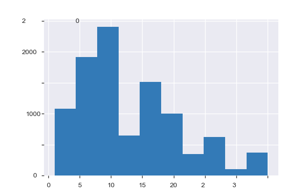

**Common Values**

| Value | Count | Frequency (%) |  |
| --- | --- | --- | --- |
| 5 | 1082 | 10.8% |  |
| 16 | 878 | 8.8% |  |
| 9 | 832 | 8.3% |  |
| 11 | 771 | 7.7% |  |
| 7 | 620 | 6.2% |  |
| 15 | 533 | 5.3% |  |
| 4 | 507 | 5.1% |  |
| 27 | 456 | 4.6% |  |
| 13 | 444 | 4.4% |  |
| 8 | 441 | 4.4% |  |
| Other values (16) | 3436 | 34.4% |  |

**Extreme Values**

Minimum 5 values

| Value | Count | Frequency (%) |  |
| --- | --- | --- | --- |
| 1 | 230 | 2.3% |  |
| 2 | 139 | 1.4% |  |
| 3 | 203 | 2.0% |  |
| 4 | 507 | 5.1% |  |
| 5 | 1082 | 10.8% |  |

Maximum 5 values

| Value | Count | Frequency (%) |  |
| --- | --- | --- | --- |
| 24 | 83 | 0.8% |  |
| 26 | 164 | 1.6% |  |
| 27 | 456 | 4.6% |  |
| 31 | 102 | 1.0% |  |
| 35 | 369 | 3.7% |  |

COMM_PT  
Numeric

| Distinct count | 12 |
| --- | --- |
| Unique (%) | 0.1% |
| Missing (%) | 0.0% |
| Missing (n) | 0 |
| Infinite (%) | 0.0% |
| Infinite (n) | 0 |

| Mean | 3.8733 |
| --- | --- |
| Minimum | 0 |
| Maximum | 19 |
| Zeros (%) | 24.6% |

Toggle details

**Statistics**

Quantile statistics

| Minimum | 0 |
| --- | --- |
| 5-th percentile | 0 |
| Q1 | 1 |
| Median | 2 |
| Q3 | 4 |
| 95-th percentile | 17 |
| Maximum | 19 |
| Range | 19 |
| Interquartile range | 3 |

Descriptive statistics

| Standard deviation | 4.935 |
| --- | --- |
| Coef of variation | 1.2741 |
| Kurtosis | 2.1916 |
| Mean | 3.8733 |
| MAD | 3.4932 |
| Skewness | 1.7623 |
| Sum | 38733 |
| Variance | 24.354 |
| Memory size | 78.2 KiB |

**Histogram**

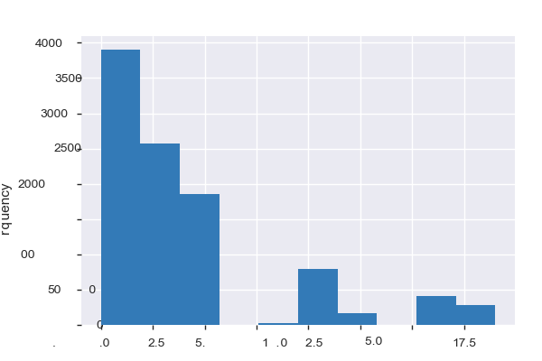

**Common Values**

| Value | Count | Frequency (%) |  |
| --- | --- | --- | --- |
| 0 | 2463 | 24.6% |  |
| 2 | 1558 | 15.6% |  |
| 1 | 1436 | 14.4% |  |
| 4 | 1387 | 13.9% |  |
| 3 | 1009 | 10.1% |  |
| 11 | 601 | 6.0% |  |
| 5 | 471 | 4.7% |  |
| 17 | 412 | 4.1% |  |
| 19 | 285 | 2.9% |  |
| 10 | 196 | 2.0% |  |
| Other values (2) | 182 | 1.8% |  |

**Extreme Values**

Minimum 5 values

| Value | Count | Frequency (%) |  |
| --- | --- | --- | --- |
| 0 | 2463 | 24.6% |  |
| 1 | 1436 | 14.4% |  |
| 2 | 1558 | 15.6% |  |
| 3 | 1009 | 10.1% |  |
| 4 | 1387 | 13.9% |  |

Maximum 5 values

| Value | Count | Frequency (%) |  |
| --- | --- | --- | --- |
| 10 | 196 | 2.0% |  |
| 11 | 601 | 6.0% |  |
| 13 | 161 | 1.6% |  |
| 17 | 412 | 4.1% |  |
| 19 | 285 | 2.9% |  |

COMM_WALK  
Numeric

| Distinct count | 10 |
| --- | --- |
| Unique (%) | 0.1% |
| Missing (%) | 0.0% |
| Missing (n) | 0 |
| Infinite (%) | 0.0% |
| Infinite (n) | 0 |

| Mean | 2.0288 |
| --- | --- |
| Minimum | 0 |
| Maximum | 33 |
| Zeros (%) | 47.2% |

Toggle details

**Statistics**

Quantile statistics

| Minimum | 0 |
| --- | --- |
| 5-th percentile | 0 |
| Q1 | 0 |
| Median | 1 |
| Q3 | 3 |
| 95-th percentile | 6 |
| Maximum | 33 |
| Range | 33 |
| Interquartile range | 3 |

Descriptive statistics

| Standard deviation | 4.4398 |
| --- | --- |
| Coef of variation | 2.1884 |
| Kurtosis | 35.289 |
| Mean | 2.0288 |
| MAD | 2.2821 |
| Skewness | 5.5226 |
| Sum | 20288 |
| Variance | 19.712 |
| Memory size | 78.2 KiB |

**Histogram**

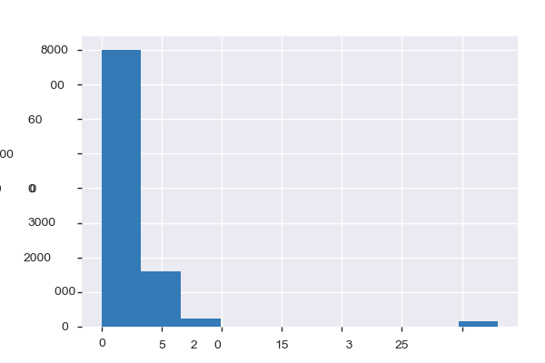

**Common Values**

| Value | Count | Frequency (%) |  |
| --- | --- | --- | --- |
| 0 | 4718 | 47.2% |  |
| 1 | 1766 | 17.7% |  |
| 3 | 759 | 7.6% |  |
| 2 | 748 | 7.5% |  |
| 4 | 726 | 7.3% |  |
| 5 | 650 | 6.5% |  |
| 6 | 232 | 2.3% |  |
| 33 | 161 | 1.6% |  |
| 7 | 135 | 1.4% |  |
| 9 | 105 | 1.1% |  |

**Extreme Values**

Minimum 5 values

| Value | Count | Frequency (%) |  |
| --- | --- | --- | --- |
| 0 | 4718 | 47.2% |  |
| 1 | 1766 | 17.7% |  |
| 2 | 748 | 7.5% |  |
| 3 | 759 | 7.6% |  |
| 4 | 726 | 7.3% |  |

Maximum 5 values

| Value | Count | Frequency (%) |  |
| --- | --- | --- | --- |
| 5 | 650 | 6.5% |  |
| 6 | 232 | 2.3% |  |
| 7 | 135 | 1.4% |  |
| 9 | 105 | 1.1% |  |
| 33 | 161 | 1.6% |  |

CULINARYIN  
Numeric

| Distinct count | 4 |
| --- | --- |
| Unique (%) | 0.0% |
| Missing (%) | 0.0% |
| Missing (n) | 0 |
| Infinite (%) | 0.0% |
| Infinite (n) | 0 |

| Mean | 0.0173 |
| --- | --- |
| Minimum | 0 |
| Maximum | 3 |
| Zeros (%) | 98.6% |

Toggle details

**Statistics**

Quantile statistics

| Minimum | 0 |
| --- | --- |
| 5-th percentile | 0 |
| Q1 | 0 |
| Median | 0 |
| Q3 | 0 |
| 95-th percentile | 0 |
| Maximum | 3 |
| Range | 3 |
| Interquartile range | 0 |

Descriptive statistics

| Standard deviation | 0.15685 |
| --- | --- |
| Coef of variation | 9.0667 |
| Kurtosis | 138.45 |
| Mean | 0.0173 |
| MAD | 0.034116 |
| Skewness | 10.839 |
| Sum | 173 |
| Variance | 0.024603 |
| Memory size | 78.2 KiB |

**Histogram**

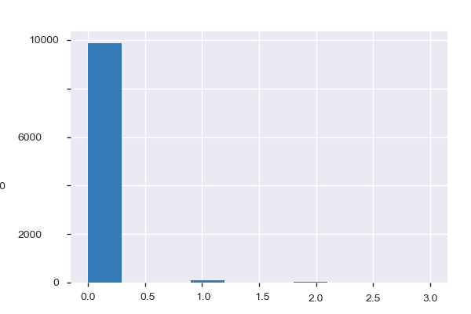

**Common Values**

| Value | Count | Frequency (%) |  |
| --- | --- | --- | --- |
| 0 | 9860 | 98.6% |  |
| 1 | 112 | 1.1% |  |
| 2 | 23 | 0.2% |  |
| 3 | 5 | 0.1% |  |

**Extreme Values**

Minimum 5 values

| Value | Count | Frequency (%) |  |
| --- | --- | --- | --- |
| 0 | 9860 | 98.6% |  |
| 1 | 112 | 1.1% |  |
| 2 | 23 | 0.2% |  |
| 3 | 5 | 0.1% |  |

Maximum 5 values

| Value | Count | Frequency (%) |  |
| --- | --- | --- | --- |
| 0 | 9860 | 98.6% |  |
| 1 | 112 | 1.1% |  |
| 2 | 23 | 0.2% |  |
| 3 | 5 | 0.1% |  |

DOITYOURSE  
Numeric

| Distinct count | 8 |
| --- | --- |
| Unique (%) | 0.1% |
| Missing (%) | 0.0% |
| Missing (n) | 0 |
| Infinite (%) | 0.0% |
| Infinite (n) | 0 |

| Mean | 0.0451 |
| --- | --- |
| Minimum | 0 |
| Maximum | 8 |
| Zeros (%) | 97.4% |

Toggle details

**Statistics**

Quantile statistics

| Minimum | 0 |
| --- | --- |
| 5-th percentile | 0 |
| Q1 | 0 |
| Median | 0 |
| Q3 | 0 |
| 95-th percentile | 0 |
| Maximum | 8 |
| Range | 8 |
| Interquartile range | 0 |

Descriptive statistics

| Standard deviation | 0.33057 |
| --- | --- |
| Coef of variation | 7.3297 |
| Kurtosis | 137.84 |
| Mean | 0.0451 |
| MAD | 0.087855 |
| Skewness | 10.324 |
| Sum | 451 |
| Variance | 0.10928 |
| Memory size | 78.2 KiB |

**Histogram**

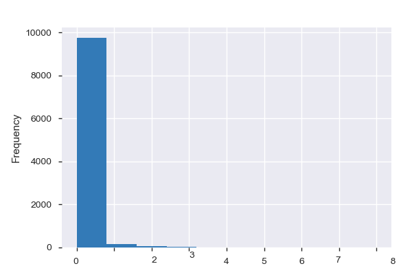

**Common Values**

| Value | Count | Frequency (%) |  |
| --- | --- | --- | --- |
| 0 | 9740 | 97.4% |  |
| 1 | 148 | 1.5% |  |
| 2 | 68 | 0.7% |  |
| 3 | 26 | 0.3% |  |
| 5 | 7 | 0.1% |  |
| 4 | 7 | 0.1% |  |
| 6 | 3 | 0.0% |  |
| 8 | 1 | 0.0% |  |

**Extreme Values**

Minimum 5 values

| Value | Count | Frequency (%) |  |
| --- | --- | --- | --- |
| 0 | 9740 | 97.4% |  |
| 1 | 148 | 1.5% |  |
| 2 | 68 | 0.7% |  |
| 3 | 26 | 0.3% |  |
| 4 | 7 | 0.1% |  |

Maximum 5 values

| Value | Count | Frequency (%) |  |
| --- | --- | --- | --- |
| 3 | 26 | 0.3% |  |
| 4 | 7 | 0.1% |  |
| 5 | 7 | 0.1% |  |
| 6 | 3 | 0.0% |  |
| 8 | 1 | 0.0% |  |

ED_4COL  
Numeric

| Distinct count | 30 |
| --- | --- |
| Unique (%) | 0.3% |
| Missing (%) | 0.0% |
| Missing (n) | 0 |
| Infinite (%) | 0.0% |
| Infinite (n) | 0 |

| Mean | 22.64 |
| --- | --- |
| Minimum | 5 |
| Maximum | 60 |
| Zeros (%) | 0.0% |

Toggle details

**Statistics**

Quantile statistics

| Minimum | 5 |
| --- | --- |
| 5-th percentile | 5 |
| Q1 | 13 |
| Median | 17 |
| Q3 | 32 |
| 95-th percentile | 44 |
| Maximum | 60 |
| Range | 55 |
| Interquartile range | 19 |

Descriptive statistics

| Standard deviation | 12.399 |
| --- | --- |
| Coef of variation | 0.54764 |
| Kurtosis | -0.40748 |
| Mean | 22.64 |
| MAD | 10.889 |
| Skewness | 0.62433 |
| Sum | 226400 |
| Variance | 153.73 |
| Memory size | 78.2 KiB |

**Histogram**

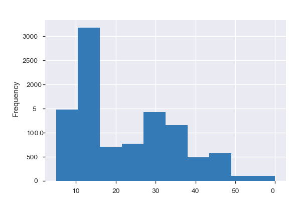

**Common Values**

| Value | Count | Frequency (%) |  |
| --- | --- | --- | --- |
| 15 | 1223 | 12.2% |  |
| 13 | 873 | 8.7% |  |
| 17 | 626 | 6.3% |  |
| 10 | 610 | 6.1% |  |
| 44 | 572 | 5.7% |  |
| 30 | 547 | 5.5% |  |
| 12 | 546 | 5.5% |  |
| 24 | 545 | 5.5% |  |
| 5 | 529 | 5.3% |  |
| 31 | 518 | 5.2% |  |
| Other values (20) | 3411 | 34.1% |  |

**Extreme Values**

Minimum 5 values

| Value | Count | Frequency (%) |  |
| --- | --- | --- | --- |
| 5 | 529 | 5.3% |  |
| 6 | 36 | 0.4% |  |
| 8 | 202 | 2.0% |  |
| 9 | 103 | 1.0% |  |
| 10 | 610 | 6.1% |  |

Maximum 5 values

| Value | Count | Frequency (%) |  |
| --- | --- | --- | --- |
| 43 | 33 | 0.3% |  |
| 44 | 572 | 5.7% |  |
| 49 | 1 | 0.0% |  |
| 54 | 106 | 1.1% |  |
| 60 | 108 | 1.1% |  |

E_PELIG  
Numeric

| Distinct count | 27 |
| --- | --- |
| Unique (%) | 0.3% |
| Missing (%) | 0.0% |
| Missing (n) | 0 |
| Infinite (%) | 0.0% |
| Infinite (n) | 0 |

| Mean | 40.541 |
| --- | --- |
| Minimum | 0 |
| Maximum | 100 |
| Zeros (%) | 18.9% |

Toggle details

**Statistics**

Quantile statistics

| Minimum | 0 |
| --- | --- |
| 5-th percentile | 0 |
| Q1 | 20 |
| Median | 40 |
| Q3 | 60 |
| 95-th percentile | 90 |
| Maximum | 100 |
| Range | 100 |
| Interquartile range | 40 |

Descriptive statistics

| Standard deviation | 28.584 |
| --- | --- |
| Coef of variation | 0.70506 |
| Kurtosis | -0.82793 |
| Mean | 40.541 |
| MAD | 23.664 |
| Skewness | 0.14868 |
| Sum | 405415 |
| Variance | 817.07 |
| Memory size | 78.2 KiB |

**Histogram**

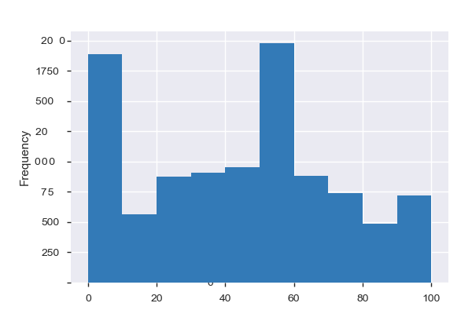

**Common Values**

| Value | Count | Frequency (%) |  |
| --- | --- | --- | --- |
| 50 | 1937 | 19.4% |  |
| 0 | 1886 | 18.9% |  |
| 40 | 878 | 8.8% |  |
| 60 | 775 | 7.8% |  |
| 70 | 657 | 6.6% |  |
| 30 | 639 | 6.4% |  |
| 20 | 526 | 5.3% |  |
| 80 | 457 | 4.6% |  |
| 10 | 382 | 3.8% |  |
| 100 | 376 | 3.8% |  |
| Other values (17) | 1487 | 14.9% |  |

**Extreme Values**

Minimum 5 values

| Value | Count | Frequency (%) |  |
| --- | --- | --- | --- |
| 0 | 1886 | 18.9% |  |
| 10 | 382 | 3.8% |  |
| 11 | 66 | 0.7% |  |
| 13 | 80 | 0.8% |  |
| 17 | 37 | 0.4% |  |

Maximum 5 values

| Value | Count | Frequency (%) |  |
| --- | --- | --- | --- |
| 83 | 6 | 0.1% |  |
| 88 | 5 | 0.1% |  |
| 89 | 20 | 0.2% |  |
| 90 | 345 | 3.5% |  |
| 100 | 376 | 3.8% |  |

FAMILYMAGA  
Numeric

| Distinct count | 8 |
| --- | --- |
| Unique (%) | 0.1% |
| Missing (%) | 0.0% |
| Missing (n) | 0 |
| Infinite (%) | 0.0% |
| Infinite (n) | 0 |

| Mean | 0.6171 |
| --- | --- |
| Minimum | 0 |
| Maximum | 9 |
| Zeros (%) | 41.7% |

Toggle details

**Statistics**

Quantile statistics

| Minimum | 0 |
| --- | --- |
| 5-th percentile | 0 |
| Q1 | 0 |
| Median | 1 |
| Q3 | 1 |
| 95-th percentile | 1 |
| Maximum | 9 |
| Range | 9 |
| Interquartile range | 1 |

Descriptive statistics

| Standard deviation | 0.59019 |
| --- | --- |
| Coef of variation | 0.95639 |
| Kurtosis | 10.112 |
| Mean | 0.6171 |
| MAD | 0.51429 |
| Skewness | 1.4019 |
| Sum | 6171 |
| Variance | 0.34832 |
| Memory size | 78.2 KiB |

**Histogram**

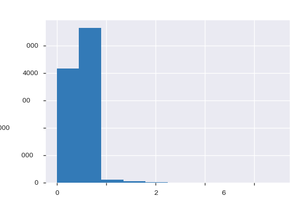

**Common Values**

| Value | Count | Frequency (%) |  |
| --- | --- | --- | --- |
| 1 | 5636 | 56.4% |  |
| 0 | 4167 | 41.7% |  |
| 2 | 106 | 1.1% |  |
| 3 | 58 | 0.6% |  |
| 4 | 24 | 0.2% |  |
| 6 | 4 | 0.0% |  |
| 5 | 4 | 0.0% |  |
| 9 | 1 | 0.0% |  |

**Extreme Values**

Minimum 5 values

| Value | Count | Frequency (%) |  |
| --- | --- | --- | --- |
| 0 | 4167 | 41.7% |  |
| 1 | 5636 | 56.4% |  |
| 2 | 106 | 1.1% |  |
| 3 | 58 | 0.6% |  |
| 4 | 24 | 0.2% |  |

Maximum 5 values

| Value | Count | Frequency (%) |  |
| --- | --- | --- | --- |
| 3 | 58 | 0.6% |  |
| 4 | 24 | 0.2% |  |
| 5 | 4 | 0.0% |  |
| 6 | 4 | 0.0% |  |
| 9 | 1 | 0.0% |  |

FEMALEORIE  
Numeric

| Distinct count | 5 |
| --- | --- |
| Unique (%) | 0.1% |
| Missing (%) | 0.0% |
| Missing (n) | 0 |
| Infinite (%) | 0.0% |
| Infinite (n) | 0 |

| Mean | 0.0151 |
| --- | --- |
| Minimum | 0 |
| Maximum | 4 |
| Zeros (%) | 98.6% |

Toggle details

**Statistics**

Quantile statistics

| Minimum | 0 |
| --- | --- |
| 5-th percentile | 0 |
| Q1 | 0 |
| Median | 0 |
| Q3 | 0 |
| 95-th percentile | 0 |
| Maximum | 4 |
| Range | 4 |
| Interquartile range | 0 |

Descriptive statistics

| Standard deviation | 0.13665 |
| --- | --- |
| Coef of variation | 9.0498 |
| Kurtosis | 190.62 |
| Mean | 0.0151 |
| MAD | 0.029783 |
| Skewness | 11.701 |
| Sum | 151 |
| Variance | 0.018674 |
| Memory size | 78.2 KiB |

**Histogram**

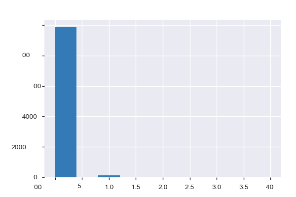

**Common Values**

| Value | Count | Frequency (%) |  |
| --- | --- | --- | --- |
| 0 | 9862 | 98.6% |  |
| 1 | 130 | 1.3% |  |
| 2 | 4 | 0.0% |  |
| 3 | 3 | 0.0% |  |
| 4 | 1 | 0.0% |  |

**Extreme Values**

Minimum 5 values

| Value | Count | Frequency (%) |  |
| --- | --- | --- | --- |
| 0 | 9862 | 98.6% |  |
| 1 | 130 | 1.3% |  |
| 2 | 4 | 0.0% |  |
| 3 | 3 | 0.0% |  |
| 4 | 1 | 0.0% |  |

Maximum 5 values

| Value | Count | Frequency (%) |  |
| --- | --- | --- | --- |
| 0 | 9862 | 98.6% |  |
| 1 | 130 | 1.3% |  |
| 2 | 4 | 0.0% |  |
| 3 | 3 | 0.0% |  |
| 4 | 1 | 0.0% |  |

FINANCIALM  
Numeric

| Distinct count | 9 |
| --- | --- |
| Unique (%) | 0.1% |
| Missing (%) | 0.0% |
| Missing (n) | 0 |
| Infinite (%) | 0.0% |
| Infinite (n) | 0 |

| Mean | 0.1438 |
| --- | --- |
| Minimum | 0 |
| Maximum | 9 |
| Zeros (%) | 87.7% |

Toggle details

**Statistics**

Quantile statistics

| Minimum | 0 |
| --- | --- |
| 5-th percentile | 0 |
| Q1 | 0 |
| Median | 0 |
| Q3 | 0 |
| 95-th percentile | 1 |
| Maximum | 9 |
| Range | 9 |
| Interquartile range | 0 |

Descriptive statistics

| Standard deviation | 0.46189 |
| --- | --- |
| Coef of variation | 3.212 |
| Kurtosis | 63.271 |
| Mean | 0.1438 |
| MAD | 0.25223 |
| Skewness | 6.0927 |
| Sum | 1438 |
| Variance | 0.21334 |
| Memory size | 78.2 KiB |

**Histogram**

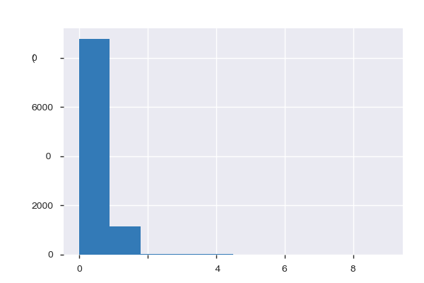

**Common Values**

| Value | Count | Frequency (%) |  |
| --- | --- | --- | --- |
| 0 | 8770 | 87.7% |  |
| 1 | 1140 | 11.4% |  |
| 2 | 38 | 0.4% |  |
| 3 | 19 | 0.2% |  |
| 4 | 15 | 0.1% |  |
| 5 | 11 | 0.1% |  |
| 7 | 5 | 0.1% |  |
| 6 | 1 | 0.0% |  |
| 9 | 1 | 0.0% |  |

**Extreme Values**

Minimum 5 values

| Value | Count | Frequency (%) |  |
| --- | --- | --- | --- |
| 0 | 8770 | 87.7% |  |
| 1 | 1140 | 11.4% |  |
| 2 | 38 | 0.4% |  |
| 3 | 19 | 0.2% |  |
| 4 | 15 | 0.1% |  |

Maximum 5 values

| Value | Count | Frequency (%) |  |
| --- | --- | --- | --- |
| 4 | 15 | 0.1% |  |
| 5 | 11 | 0.1% |  |
| 6 | 1 | 0.0% |  |
| 7 | 5 | 0.1% |  |
| 9 | 1 | 0.0% |  |

F_MAR  
Numeric

| Distinct count | 35 |
| --- | --- |
| Unique (%) | 0.4% |
| Missing (%) | 0.0% |
| Missing (n) | 0 |
| Infinite (%) | 0.0% |
| Infinite (n) | 0 |

| Mean | 49.264 |
| --- | --- |
| Minimum | 10 |
| Maximum | 75 |
| Zeros (%) | 0.0% |

Toggle details

**Statistics**

Quantile statistics

| Minimum | 10 |
| --- | --- |
| 5-th percentile | 26 |
| Q1 | 43 |
| Median | 50 |
| Q3 | 59 |
| 95-th percentile | 70 |
| Maximum | 75 |
| Range | 65 |
| Interquartile range | 16 |

Descriptive statistics

| Standard deviation | 12.572 |
| --- | --- |
| Coef of variation | 0.25519 |
| Kurtosis | 0.92468 |
| Mean | 49.264 |
| MAD | 9.3059 |
| Skewness | -0.70096 |
| Sum | 492645 |
| Variance | 158.05 |
| Memory size | 78.2 KiB |

**Histogram**

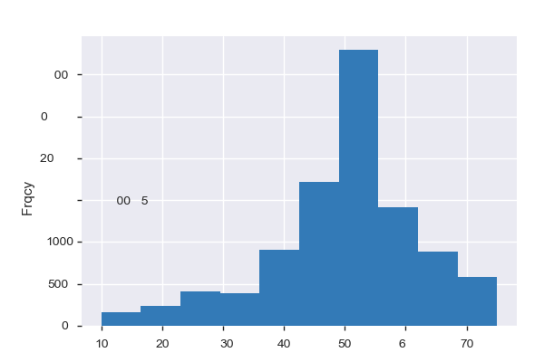

**Common Values**

| Value | Count | Frequency (%) |  |
| --- | --- | --- | --- |
| 46 | 924 | 9.2% |  |
| 49 | 923 | 9.2% |  |
| 54 | 860 | 8.6% |  |
| 60 | 779 | 7.8% |  |
| 50 | 682 | 6.8% |  |
| 43 | 583 | 5.8% |  |
| 38 | 505 | 5.1% |  |
| 62 | 504 | 5.0% |  |
| 51 | 481 | 4.8% |  |
| 26 | 412 | 4.1% |  |
| Other values (25) | 3347 | 33.5% |  |

**Extreme Values**

Minimum 5 values

| Value | Count | Frequency (%) |  |
| --- | --- | --- | --- |
| 10 | 161 | 1.6% |  |
| 18 | 238 | 2.4% |  |
| 26 | 412 | 4.1% |  |
| 28 | 4 | 0.0% |  |
| 34 | 285 | 2.9% |  |

Maximum 5 values

| Value | Count | Frequency (%) |  |
| --- | --- | --- | --- |
| 70 | 135 | 1.4% |  |
| 72 | 75 | 0.8% |  |
| 73 | 108 | 1.1% |  |
| 74 | 195 | 1.9% |  |
| 75 | 8 | 0.1% |  |

GARDENINGM  
Numeric

| Distinct count | 6 |
| --- | --- |
| Unique (%) | 0.1% |
| Missing (%) | 0.0% |
| Missing (n) | 0 |
| Infinite (%) | 0.0% |
| Infinite (n) | 0 |

| Mean | 0.0305 |
| --- | --- |
| Minimum | 0 |
| Maximum | 5 |
| Zeros (%) | 98.4% |

Toggle details

**Statistics**

Quantile statistics

| Minimum | 0 |
| --- | --- |
| 5-th percentile | 0 |
| Q1 | 0 |
| Median | 0 |
| Q3 | 0 |
| 95-th percentile | 0 |
| Maximum | 5 |
| Range | 5 |
| Interquartile range | 0 |

Descriptive statistics

| Standard deviation | 0.27491 |
| --- | --- |
| Coef of variation | 9.0135 |
| Kurtosis | 137.44 |
| Mean | 0.0305 |
| MAD | 0.06 |
| Skewness | 11.071 |
| Sum | 305 |
| Variance | 0.075577 |
| Memory size | 78.2 KiB |

**Histogram**

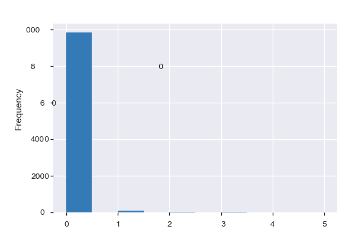

**Common Values**

| Value | Count | Frequency (%) |  |
| --- | --- | --- | --- |
| 0 | 9836 | 98.4% |  |
| 1 | 90 | 0.9% |  |
| 3 | 32 | 0.3% |  |
| 2 | 26 | 0.3% |  |
| 4 | 13 | 0.1% |  |
| 5 | 3 | 0.0% |  |

**Extreme Values**

Minimum 5 values

| Value | Count | Frequency (%) |  |
| --- | --- | --- | --- |
| 0 | 9836 | 98.4% |  |
| 1 | 90 | 0.9% |  |
| 2 | 26 | 0.3% |  |
| 3 | 32 | 0.3% |  |
| 4 | 13 | 0.1% |  |

Maximum 5 values

| Value | Count | Frequency (%) |  |
| --- | --- | --- | --- |
| 1 | 90 | 0.9% |  |
| 2 | 26 | 0.3% |  |
| 3 | 32 | 0.3% |  |
| 4 | 13 | 0.1% |  |
| 5 | 3 | 0.0% |  |

GENDER_F  
Boolean

| Distinct count | 2 |
| --- | --- |
| Unique (%) | 0.0% |
| Missing (%) | 0.0% |
| Missing (n) | 0 |

| Mean | 0.5704 |
| --- | --- |

| 1 | 5704 |
| --- | --- |
| 0 | 4296 |

Toggle details

| Value | Count | Frequency (%) |  |
| --- | --- | --- | --- |
| 1 | 5704 | 57.0% |  |
| 0 | 4296 | 43.0% |  |

GENDER_M  
Boolean

| Distinct count | 2 |
| --- | --- |
| Unique (%) | 0.0% |
| Missing (%) | 0.0% |
| Missing (n) | 0 |

| Mean | 0.4296 |
| --- | --- |

| 0 | 5704 |
| --- | --- |
| 1 | 4296 |

Toggle details

| Value | Count | Frequency (%) |  |
| --- | --- | --- | --- |
| 0 | 5704 | 57.0% |  |
| 1 | 4296 | 43.0% |  |

G_PELIG  
Numeric

| Distinct count | 11 |
| --- | --- |
| Unique (%) | 0.1% |
| Missing (%) | 0.0% |
| Missing (n) | 0 |
| Infinite (%) | 0.0% |
| Infinite (n) | 0 |

| Mean | 64.948 |
| --- | --- |
| Minimum | 0 |
| Maximum | 100 |
| Zeros (%) | 19.0% |

Toggle details

**Statistics**

Quantile statistics

| Minimum | 0 |
| --- | --- |
| 5-th percentile | 0 |
| Q1 | 33 |
| Median | 80 |
| Q3 | 100 |
| 95-th percentile | 100 |
| Maximum | 100 |
| Range | 100 |
| Interquartile range | 67 |

Descriptive statistics

| Standard deviation | 38.913 |
| --- | --- |
| Coef of variation | 0.59914 |
| Kurtosis | -1.1385 |
| Mean | 64.948 |
| MAD | 34.24 |
| Skewness | -0.65575 |
| Sum | 649482 |
| Variance | 1514.2 |
| Memory size | 78.2 KiB |

**Histogram**

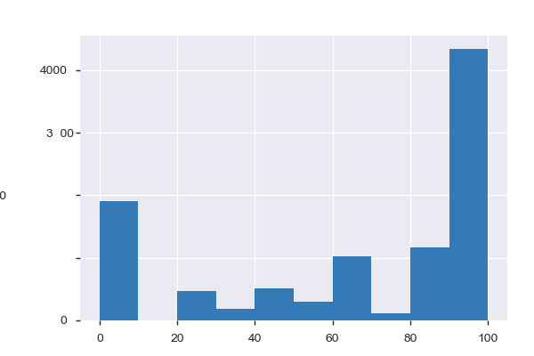

**Common Values**

| Value | Count | Frequency (%) |  |
| --- | --- | --- | --- |
| 100 | 4335 | 43.4% |  |
| 0 | 1903 | 19.0% |  |
| 80 | 1168 | 11.7% |  |
| 60 | 749 | 7.5% |  |
| 40 | 513 | 5.1% |  |
| 20 | 394 | 3.9% |  |
| 50 | 294 | 2.9% |  |
| 67 | 270 | 2.7% |  |
| 33 | 189 | 1.9% |  |
| 75 | 111 | 1.1% |  |

**Extreme Values**

Minimum 5 values

| Value | Count | Frequency (%) |  |
| --- | --- | --- | --- |
| 0 | 1903 | 19.0% |  |
| 20 | 394 | 3.9% |  |
| 25 | 74 | 0.7% |  |
| 33 | 189 | 1.9% |  |
| 40 | 513 | 5.1% |  |

Maximum 5 values

| Value | Count | Frequency (%) |  |
| --- | --- | --- | --- |
| 60 | 749 | 7.5% |  |
| 67 | 270 | 2.7% |  |
| 75 | 111 | 1.1% |  |
| 80 | 1168 | 11.7% |  |
| 100 | 4335 | 43.4% |  |

HEALTHFITN  
Numeric

| Distinct count | 10 |
| --- | --- |
| Unique (%) | 0.1% |
| Missing (%) | 0.0% |
| Missing (n) | 0 |
| Infinite (%) | 0.0% |
| Infinite (n) | 0 |

| Mean | 0.9734 |
| --- | --- |
| Minimum | 0 |
| Maximum | 9 |
| Zeros (%) | 11.8% |

Toggle details

**Statistics**

Quantile statistics

| Minimum | 0 |
| --- | --- |
| 5-th percentile | 0 |
| Q1 | 1 |
| Median | 1 |
| Q3 | 1 |
| 95-th percentile | 1 |
| Maximum | 9 |
| Range | 9 |
| Interquartile range | 0 |

Descriptive statistics

| Standard deviation | 0.67686 |
| --- | --- |
| Coef of variation | 0.69536 |
| Kurtosis | 44.297 |
| Mean | 0.9734 |
| MAD | 0.2307 |
| Skewness | 5.1031 |
| Sum | 9734 |
| Variance | 0.45814 |
| Memory size | 78.2 KiB |

**Histogram**

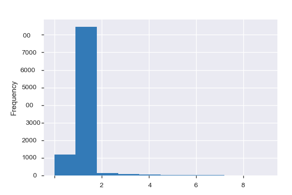

**Common Values**

| Value | Count | Frequency (%) |  |
| --- | --- | --- | --- |
| 1 | 8448 | 84.5% |  |
| 0 | 1185 | 11.8% |  |
| 2 | 135 | 1.4% |  |
| 3 | 92 | 0.9% |  |
| 4 | 64 | 0.6% |  |
| 5 | 25 | 0.2% |  |
| 6 | 22 | 0.2% |  |
| 7 | 14 | 0.1% |  |
| 9 | 9 | 0.1% |  |
| 8 | 6 | 0.1% |  |

**Extreme Values**

Minimum 5 values

| Value | Count | Frequency (%) |  |
| --- | --- | --- | --- |
| 0 | 1185 | 11.8% |  |
| 1 | 8448 | 84.5% |  |
| 2 | 135 | 1.4% |  |
| 3 | 92 | 0.9% |  |
| 4 | 64 | 0.6% |  |

Maximum 5 values

| Value | Count | Frequency (%) |  |
| --- | --- | --- | --- |
| 5 | 25 | 0.2% |  |
| 6 | 22 | 0.2% |  |
| 7 | 14 | 0.1% |  |
| 8 | 6 | 0.1% |  |
| 9 | 9 | 0.1% |  |

HH_ND  
Numeric

| Distinct count | 10 |
| --- | --- |
| Unique (%) | 0.1% |
| Missing (%) | 0.0% |
| Missing (n) | 0 |
| Infinite (%) | 0.0% |
| Infinite (n) | 0 |

| Mean | 1.2118 |
| --- | --- |
| Minimum | 0 |
| Maximum | 9 |
| Zeros (%) | 36.9% |

Toggle details

**Statistics**

Quantile statistics

| Minimum | 0 |
| --- | --- |
| 5-th percentile | 0 |
| Q1 | 0 |
| Median | 1 |
| Q3 | 2 |
| 95-th percentile | 4 |
| Maximum | 9 |
| Range | 9 |
| Interquartile range | 2 |

Descriptive statistics

| Standard deviation | 1.31 |
| --- | --- |
| Coef of variation | 1.081 |
| Kurtosis | 4.2306 |
| Mean | 1.2118 |
| MAD | 1.0142 |
| Skewness | 1.549 |
| Sum | 12118 |
| Variance | 1.7161 |
| Memory size | 78.2 KiB |

**Histogram**

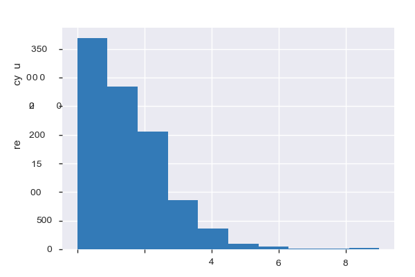

**Common Values**

| Value | Count | Frequency (%) |  |
| --- | --- | --- | --- |
| 0 | 3687 | 36.9% |  |
| 1 | 2848 | 28.5% |  |
| 2 | 2056 | 20.6% |  |
| 3 | 865 | 8.6% |  |
| 4 | 357 | 3.6% |  |
| 5 | 96 | 1.0% |  |
| 6 | 45 | 0.4% |  |
| 9 | 28 | 0.3% |  |
| 7 | 11 | 0.1% |  |
| 8 | 7 | 0.1% |  |

**Extreme Values**

Minimum 5 values

| Value | Count | Frequency (%) |  |
| --- | --- | --- | --- |
| 0 | 3687 | 36.9% |  |
| 1 | 2848 | 28.5% |  |
| 2 | 2056 | 20.6% |  |
| 3 | 865 | 8.6% |  |
| 4 | 357 | 3.6% |  |

Maximum 5 values

| Value | Count | Frequency (%) |  |
| --- | --- | --- | --- |
| 5 | 96 | 1.0% |  |
| 6 | 45 | 0.4% |  |
| 7 | 11 | 0.1% |  |
| 8 | 7 | 0.1% |  |
| 9 | 28 | 0.3% |  |

HH_NI  
Numeric

| Distinct count | 10 |
| --- | --- |
| Unique (%) | 0.1% |
| Missing (%) | 0.0% |
| Missing (n) | 0 |
| Infinite (%) | 0.0% |
| Infinite (n) | 0 |

| Mean | 0.612 |
| --- | --- |
| Minimum | 0 |
| Maximum | 9 |
| Zeros (%) | 58.5% |

Toggle details

**Statistics**

Quantile statistics

| Minimum | 0 |
| --- | --- |
| 5-th percentile | 0 |
| Q1 | 0 |
| Median | 0 |
| Q3 | 1 |
| 95-th percentile | 2 |
| Maximum | 9 |
| Range | 9 |
| Interquartile range | 1 |

Descriptive statistics

| Standard deviation | 0.92733 |
| --- | --- |
| Coef of variation | 1.5152 |
| Kurtosis | 15.346 |
| Mean | 0.612 |
| MAD | 0.71616 |
| Skewness | 2.7296 |
| Sum | 6120 |
| Variance | 0.85994 |
| Memory size | 78.2 KiB |

**Histogram**

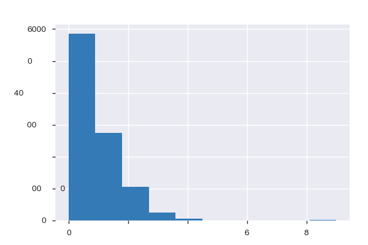

**Common Values**

| Value | Count | Frequency (%) |  |
| --- | --- | --- | --- |
| 0 | 5851 | 58.5% |  |
| 1 | 2742 | 27.4% |  |
| 2 | 1063 | 10.6% |  |
| 3 | 257 | 2.6% |  |
| 4 | 50 | 0.5% |  |
| 9 | 20 | 0.2% |  |
| 5 | 8 | 0.1% |  |
| 7 | 5 | 0.1% |  |
| 6 | 3 | 0.0% |  |
| 8 | 1 | 0.0% |  |

**Extreme Values**

Minimum 5 values

| Value | Count | Frequency (%) |  |
| --- | --- | --- | --- |
| 0 | 5851 | 58.5% |  |
| 1 | 2742 | 27.4% |  |
| 2 | 1063 | 10.6% |  |
| 3 | 257 | 2.6% |  |
| 4 | 50 | 0.5% |  |

Maximum 5 values

| Value | Count | Frequency (%) |  |
| --- | --- | --- | --- |
| 5 | 8 | 0.1% |  |
| 6 | 3 | 0.0% |  |
| 7 | 5 | 0.1% |  |
| 8 | 1 | 0.0% |  |
| 9 | 20 | 0.2% |  |

HH_NR  
Numeric

| Distinct count | 10 |
| --- | --- |
| Unique (%) | 0.1% |
| Missing (%) | 0.0% |
| Missing (n) | 0 |
| Infinite (%) | 0.0% |
| Infinite (n) | 0 |

| Mean | 0.7287 |
| --- | --- |
| Minimum | 0 |
| Maximum | 9 |
| Zeros (%) | 56.9% |

Toggle details

**Statistics**

Quantile statistics

| Minimum | 0 |
| --- | --- |
| 5-th percentile | 0 |
| Q1 | 0 |
| Median | 0 |
| Q3 | 1 |
| 95-th percentile | 3 |
| Maximum | 9 |
| Range | 9 |
| Interquartile range | 1 |

Descriptive statistics

| Standard deviation | 1.0622 |
| --- | --- |
| Coef of variation | 1.4576 |
| Kurtosis | 7.3242 |
| Mean | 0.7287 |
| MAD | 0.82984 |
| Skewness | 2.0681 |
| Sum | 7287 |
| Variance | 1.1282 |
| Memory size | 78.2 KiB |

**Histogram**

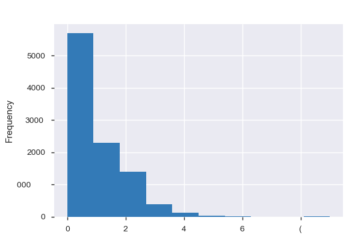

**Common Values**

| Value | Count | Frequency (%) |  |
| --- | --- | --- | --- |
| 0 | 5694 | 56.9% |  |
| 1 | 2302 | 23.0% |  |
| 2 | 1394 | 13.9% |  |
| 3 | 397 | 4.0% |  |
| 4 | 138 | 1.4% |  |
| 5 | 45 | 0.4% |  |
| 9 | 14 | 0.1% |  |
| 6 | 12 | 0.1% |  |
| 8 | 3 | 0.0% |  |
| 7 | 1 | 0.0% |  |

**Extreme Values**

Minimum 5 values

| Value | Count | Frequency (%) |  |
| --- | --- | --- | --- |
| 0 | 5694 | 56.9% |  |
| 1 | 2302 | 23.0% |  |
| 2 | 1394 | 13.9% |  |
| 3 | 397 | 4.0% |  |
| 4 | 138 | 1.4% |  |

Maximum 5 values

| Value | Count | Frequency (%) |  |
| --- | --- | --- | --- |
| 5 | 45 | 0.4% |  |
| 6 | 12 | 0.1% |  |
| 7 | 1 | 0.0% |  |
| 8 | 3 | 0.0% |  |
| 9 | 14 | 0.1% |  |

HISP  
Numeric

| Distinct count | 19 |
| --- | --- |
| Unique (%) | 0.2% |
| Missing (%) | 0.0% |
| Missing (n) | 0 |
| Infinite (%) | 0.0% |
| Infinite (n) | 0 |

| Mean | 5.8854 |
| --- | --- |
| Minimum | 0 |
| Maximum | 39 |
| Zeros (%) | 9.7% |

Toggle details

**Statistics**

Quantile statistics

| Minimum | 0 |
| --- | --- |
| 5-th percentile | 0 |
| Q1 | 2 |
| Median | 3 |
| Q3 | 6 |
| 95-th percentile | 24 |
| Maximum | 39 |
| Range | 39 |
| Interquartile range | 4 |

Descriptive statistics

| Standard deviation | 8.2327 |
| --- | --- |
| Coef of variation | 1.3988 |
| Kurtosis | 8.5798 |
| Mean | 5.8854 |
| MAD | 4.8889 |
| Skewness | 2.9413 |
| Sum | 58854 |
| Variance | 67.777 |
| Memory size | 78.2 KiB |

**Histogram**

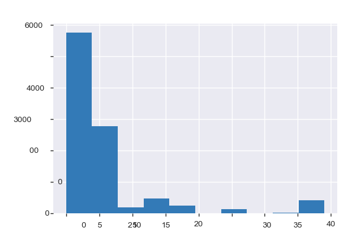

**Common Values**

| Value | Count | Frequency (%) |  |
| --- | --- | --- | --- |
| 3 | 2493 | 24.9% |  |
| 2 | 1396 | 14.0% |  |
| 6 | 1022 | 10.2% |  |
| 0 | 970 | 9.7% |  |
| 5 | 899 | 9.0% |  |
| 1 | 898 | 9.0% |  |
| 4 | 496 | 5.0% |  |
| 39 | 412 | 4.1% |  |
| 7 | 363 | 3.6% |  |
| 14 | 269 | 2.7% |  |
| Other values (9) | 782 | 7.8% |  |

**Extreme Values**

Minimum 5 values

| Value | Count | Frequency (%) |  |
| --- | --- | --- | --- |
| 0 | 970 | 9.7% |  |
| 1 | 898 | 9.0% |  |
| 2 | 1396 | 14.0% |  |
| 3 | 2493 | 24.9% |  |
| 4 | 496 | 5.0% |  |

Maximum 5 values

| Value | Count | Frequency (%) |  |
| --- | --- | --- | --- |
| 17 | 179 | 1.8% |  |
| 19 | 67 | 0.7% |  |
| 24 | 131 | 1.3% |  |
| 35 | 18 | 0.2% |  |
| 39 | 412 | 4.1% |  |

H_AFDLN3P  
Boolean

| Distinct count | 2 |
| --- | --- |
| Unique (%) | 0.0% |
| Missing (%) | 0.0% |
| Missing (n) | 0 |

| Mean | 0.0067 |
| --- | --- |

| 0 | 9933 |
| --- | --- |
| 1 | 67 |

Toggle details

| Value | Count | Frequency (%) |  |
| --- | --- | --- | --- |
| 0 | 9933 | 99.3% |  |
| 1 | 67 | 0.7% |  |

H_F1  
Boolean

| Distinct count | 2 |
| --- | --- |
| Unique (%) | 0.0% |
| Missing (%) | 0.0% |
| Missing (n) | 0 |

| Mean | 0.1163 |
| --- | --- |

| 0 | 8837 |
| --- | --- |
| 1 | 1163 |

Toggle details

| Value | Count | Frequency (%) |  |
| --- | --- | --- | --- |
| 0 | 8837 | 88.4% |  |
| 1 | 1163 | 11.6% |  |

H_M1  
Boolean

| Distinct count | 2 |
| --- | --- |
| Unique (%) | 0.0% |
| Missing (%) | 0.0% |
| Missing (n) | 0 |

| Mean | 0.0687 |
| --- | --- |

| 0 | 9313 |
| --- | --- |
| 1 | 687 |

Toggle details

| Value | Count | Frequency (%) |  |
| --- | --- | --- | --- |
| 0 | 9313 | 93.1% |  |
| 1 | 687 | 6.9% |  |

H_MFDLN3P  
Boolean

| Distinct count | 2 |
| --- | --- |
| Unique (%) | 0.0% |
| Missing (%) | 0.0% |
| Missing (n) | 0 |

| Mean | 0.0393 |
| --- | --- |

| 0 | 9607 |
| --- | --- |
| 1 | 393 |

Toggle details

| Value | Count | Frequency (%) |  |
| --- | --- | --- | --- |
| 0 | 9607 | 96.1% |  |
| 1 | 393 | 3.9% |  |

I3  
Categorical

| Distinct count | 2 |
| --- | --- |
| Unique (%) | 0.0% |
| Missing (%) | 0.0% |
| Missing (n) | 0 |

| N | 7598 |
| --- | --- |
| Y | 2402 |

Toggle details

| Value | Count | Frequency (%) |  |
| --- | --- | --- | --- |
| N | 7598 | 76.0% |  |
| Y | 2402 | 24.0% |  |

KIDS  
Numeric

| Distinct count | 24 |
| --- | --- |
| Unique (%) | 0.2% |
| Missing (%) | 0.0% |
| Missing (n) | 0 |
| Infinite (%) | 0.0% |
| Infinite (n) | 0 |

| Mean | 19.238 |
| --- | --- |
| Minimum | 3 |
| Maximum | 31 |
| Zeros (%) | 0.0% |

Toggle details

**Statistics**

Quantile statistics

| Minimum | 3 |
| --- | --- |
| 5-th percentile | 11 |
| Q1 | 15 |
| Median | 19 |
| Q3 | 25 |
| 95-th percentile | 30 |
| Maximum | 31 |
| Range | 28 |
| Interquartile range | 10 |

Descriptive statistics

| Standard deviation | 6.1575 |
| --- | --- |
| Coef of variation | 0.32006 |
| Kurtosis | -0.51229 |
| Mean | 19.238 |
| MAD | 4.7927 |
| Skewness | -0.0014962 |
| Sum | 192383 |
| Variance | 37.915 |
| Memory size | 78.2 KiB |

**Histogram**

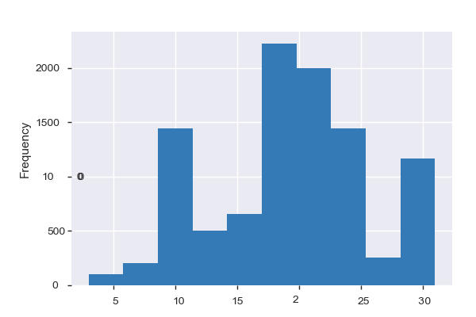

**Common Values**

| Value | Count | Frequency (%) |  |
| --- | --- | --- | --- |
| 20 | 1752 | 17.5% |  |
| 11 | 1250 | 12.5% |  |
| 19 | 1175 | 11.8% |  |
| 25 | 1146 | 11.5% |  |
| 17 | 842 | 8.4% |  |
| 29 | 648 | 6.5% |  |
| 14 | 424 | 4.2% |  |
| 15 | 417 | 4.2% |  |
| 31 | 368 | 3.7% |  |
| 27 | 256 | 2.6% |  |
| Other values (14) | 1722 | 17.2% |  |

**Extreme Values**

Minimum 5 values

| Value | Count | Frequency (%) |  |
| --- | --- | --- | --- |
| 3 | 8 | 0.1% |  |
| 4 | 93 | 0.9% |  |
| 6 | 8 | 0.1% |  |
| 7 | 160 | 1.6% |  |
| 8 | 33 | 0.3% |  |

Maximum 5 values

| Value | Count | Frequency (%) |  |
| --- | --- | --- | --- |
| 25 | 1146 | 11.5% |  |
| 27 | 256 | 2.6% |  |
| 29 | 648 | 6.5% |  |
| 30 | 154 | 1.5% |  |
| 31 | 368 | 3.7% |  |

MEDIANEDUC  
Numeric

| Distinct count | 7 |
| --- | --- |
| Unique (%) | 0.1% |
| Missing (%) | 0.0% |
| Missing (n) | 0 |
| Infinite (%) | 0.0% |
| Infinite (n) | 0 |

| Mean | 12.603 |
| --- | --- |
| Minimum | 8 |
| Maximum | 16 |
| Zeros (%) | 0.0% |

Toggle details

**Statistics**

Quantile statistics

| Minimum | 8 |
| --- | --- |
| 5-th percentile | 12 |
| Q1 | 12 |
| Median | 12 |
| Q3 | 13 |
| 95-th percentile | 15 |
| Maximum | 16 |
| Range | 8 |
| Interquartile range | 1 |

Descriptive statistics

| Standard deviation | 1.0902 |
| --- | --- |
| Coef of variation | 0.086505 |
| Kurtosis | 1.185 |
| Mean | 12.603 |
| MAD | 0.87128 |
| Skewness | 1.2528 |
| Sum | 126028 |
| Variance | 1.1886 |
| Memory size | 78.2 KiB |

**Histogram**

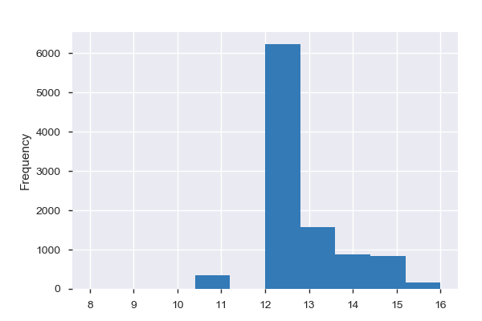

**Common Values**

| Value | Count | Frequency (%) |  |
| --- | --- | --- | --- |
| 12 | 6220 | 62.2% |  |
| 13 | 1564 | 15.6% |  |
| 14 | 869 | 8.7% |  |
| 15 | 832 | 8.3% |  |
| 11 | 350 | 3.5% |  |
| 16 | 155 | 1.6% |  |
| 8 | 10 | 0.1% |  |

**Extreme Values**

Minimum 5 values

| Value | Count | Frequency (%) |  |
| --- | --- | --- | --- |
| 8 | 10 | 0.1% |  |
| 11 | 350 | 3.5% |  |
| 12 | 6220 | 62.2% |  |
| 13 | 1564 | 15.6% |  |
| 14 | 869 | 8.7% |  |

Maximum 5 values

| Value | Count | Frequency (%) |  |
| --- | --- | --- | --- |
| 12 | 6220 | 62.2% |  |
| 13 | 1564 | 15.6% |  |
| 14 | 869 | 8.7% |  |
| 15 | 832 | 8.3% |  |
| 16 | 155 | 1.6% |  |

MED_AGE  
Numeric

| Distinct count | 28 |
| --- | --- |
| Unique (%) | 0.3% |
| Missing (%) | 0.0% |
| Missing (n) | 0 |
| Infinite (%) | 0.0% |
| Infinite (n) | 0 |

| Mean | 39.162 |
| --- | --- |
| Minimum | 25 |
| Maximum | 65 |
| Zeros (%) | 0.0% |

Toggle details

**Statistics**

Quantile statistics

| Minimum | 25 |
| --- | --- |
| 5-th percentile | 32 |
| Q1 | 34 |
| Median | 38 |
| Q3 | 44 |
| 95-th percentile | 53 |
| Maximum | 65 |
| Range | 40 |
| Interquartile range | 10 |

Descriptive statistics

| Standard deviation | 6.8976 |
| --- | --- |
| Coef of variation | 0.17613 |
| Kurtosis | 0.26351 |
| Mean | 39.162 |
| MAD | 5.4622 |
| Skewness | 0.58141 |
| Sum | 391617 |
| Variance | 47.576 |
| Memory size | 78.2 KiB |

**Histogram**

[figure not shown]

**Common Values**

| Value | Count | Frequency (%) |  |
| --- | --- | --- | --- |
| 34 | 1111 | 11.1% |  |
| 38 | 994 | 9.9% |  |
| 32 | 933 | 9.3% |  |
| 41 | 727 | 7.3% |  |
| 33 | 704 | 7.0% |  |
| 36 | 656 | 6.6% |  |
| 50 | 630 | 6.3% |  |
| 37 | 571 | 5.7% |  |
| 45 | 449 | 4.5% |  |
| 40 | 448 | 4.5% |  |
| Other values (18) | 2777 | 27.8% |  |

**Extreme Values**

Minimum 5 values

| Value | Count | Frequency (%) |  |
| --- | --- | --- | --- |
| 25 | 368 | 3.7% |  |
| 30 | 4 | 0.0% |  |
| 31 | 18 | 0.2% |  |
| 32 | 933 | 9.3% |  |
| 33 | 704 | 7.0% |  |

Maximum 5 values

| Value | Count | Frequency (%) |  |
| --- | --- | --- | --- |
| 54 | 4 | 0.0% |  |
| 55 | 196 | 2.0% |  |
| 56 | 93 | 0.9% |  |
| 62 | 41 | 0.4% |  |
| 65 | 8 | 0.1% |  |

MED_HH_INC  
Numeric

| Distinct count | 60 |
| --- | --- |
| Unique (%) | 0.6% |
| Missing (%) | 0.0% |
| Missing (n) | 0 |
| Infinite (%) | 0.0% |
| Infinite (n) | 0 |

| Mean | 70161 |
| --- | --- |
| Minimum | 22381 |
| Maximum | 200227 |
| Zeros (%) | 0.0% |

Toggle details

**Statistics**

Quantile statistics

| Minimum | 22381 |
| --- | --- |
| 5-th percentile | 37772 |
| Q1 | 51797 |
| Median | 59802 |
| Q3 | 84476 |
| 95-th percentile | 125150 |
| Maximum | 200227 |
| Range | 177846 |
| Interquartile range | 32679 |

Descriptive statistics

| Standard deviation | 25683 |
| --- | --- |
| Coef of variation | 0.36606 |
| Kurtosis | 2.1585 |
| Mean | 70161 |
| MAD | 20761 |
| Skewness | 1.055 |
| Sum | 701606716 |
| Variance | 659610000 |
| Memory size | 78.2 KiB |

**Histogram**

[figure not shown]

**Common Values**

| Value | Count | Frequency (%) |  |
| --- | --- | --- | --- |
| 58950 | 601 | 6.0% |  |
| 84333 | 572 | 5.7% |  |
| 92170 | 545 | 5.5% |  |
| 81506 | 469 | 4.7% |  |
| 125154 | 464 | 4.6% |  |
| 59802 | 419 | 4.2% |  |
| 46125 | 412 | 4.1% |  |
| 58145 | 368 | 3.7% |  |
| 57414 | 367 | 3.7% |  |
| 95272 | 350 | 3.5% |  |
| Other values (50) | 5433 | 54.3% |  |

**Extreme Values**

Minimum 5 values

| Value | Count | Frequency (%) |  |
| --- | --- | --- | --- |
| 22381 | 238 | 2.4% |  |
| 28730 | 161 | 1.6% |  |
| 33500 | 4 | 0.0% |  |
| 37772 | 100 | 1.0% |  |
| 41477 | 119 | 1.2% |  |

Maximum 5 values

| Value | Count | Frequency (%) |  |
| --- | --- | --- | --- |
| 120417 | 105 | 1.1% |  |
| 125154 | 464 | 4.6% |  |
| 129018 | 1 | 0.0% |  |
| 176953 | 108 | 1.1% |  |
| 200227 | 1 | 0.0% |  |

MESSAGE_A  
Boolean

| Distinct count | 2 |
| --- | --- |
| Unique (%) | 0.0% |
| Missing (%) | 0.0% |
| Missing (n) | 0 |

| Mean | 0.5 |
| --- | --- |

| 1 | 5000 |
| --- | --- |
| 0 | 5000 |

Toggle details

| Value | Count | Frequency (%) |  |
| --- | --- | --- | --- |
| 1 | 5000 | 50.0% |  |
| 0 | 5000 | 50.0% |  |

MESSAGE_A_REV  
Boolean

| Distinct count | 2 |
| --- | --- |
| Unique (%) | 0.0% |
| Missing (%) | 0.0% |
| Missing (n) | 0 |

| Mean | 0.5 |
| --- | --- |

| 1 | 5000 |
| --- | --- |
| 0 | 5000 |

Toggle details

| Value | Count | Frequency (%) |  |
| --- | --- | --- | --- |
| 1 | 5000 | 50.0% |  |
| 0 | 5000 | 50.0% |  |

MOVED_A  
Boolean

| Distinct count | 2 |
| --- | --- |
| Unique (%) | 0.0% |
| Missing (%) | 0.0% |
| Missing (n) | 0 |

| Mean | 0.3734 |
| --- | --- |

| 0 | 6266 |
| --- | --- |
| 1 | 3734 |

Toggle details

| Value | Count | Frequency (%) |  |
| --- | --- | --- | --- |
| 0 | 6266 | 62.7% |  |
| 1 | 3734 | 37.3% |  |

MOVED_AD  
Categorical

| Distinct count | 2 |
| --- | --- |
| Unique (%) | 0.0% |
| Missing (%) | 0.0% |
| Missing (n) | 0 |

| N | 6266 |
| --- | --- |
| Y | 3734 |

Toggle details

| Value | Count | Frequency (%) |  |
| --- | --- | --- | --- |
| N | 6266 | 62.7% |  |
| Y | 3734 | 37.3% |  |

M_MAR  
Numeric

| Distinct count | 32 |
| --- | --- |
| Unique (%) | 0.3% |
| Missing (%) | 0.0% |
| Missing (n) | 0 |
| Infinite (%) | 0.0% |
| Infinite (n) | 0 |

| Mean | 51.343 |
| --- | --- |
| Minimum | 15 |
| Maximum | 89 |
| Zeros (%) | 0.0% |

Toggle details

**Statistics**

Quantile statistics

| Minimum | 15 |
| --- | --- |
| 5-th percentile | 24 |
| Q1 | 44 |
| Median | 52 |
| Q3 | 59 |
| 95-th percentile | 71 |
| Maximum | 89 |
| Range | 74 |
| Interquartile range | 15 |

Descriptive statistics

| Standard deviation | 12.335 |
| --- | --- |
| Coef of variation | 0.24024 |
| Kurtosis | 0.75833 |
| Mean | 51.343 |
| MAD | 9.4145 |
| Skewness | -0.63584 |
| Sum | 513434 |
| Variance | 152.14 |
| Memory size | 78.2 KiB |

**Histogram**

[figure not shown]

**Common Values**

| Value | Count | Frequency (%) |  |
| --- | --- | --- | --- |
| 48 | 891 | 8.9% |  |
| 58 | 766 | 7.7% |  |
| 50 | 706 | 7.1% |  |
| 43 | 660 | 6.6% |  |
| 52 | 588 | 5.9% |  |
| 71 | 575 | 5.8% |  |
| 54 | 487 | 4.9% |  |
| 61 | 460 | 4.6% |  |
| 34 | 430 | 4.3% |  |
| 63 | 425 | 4.2% |  |
| Other values (22) | 4012 | 40.1% |  |

**Extreme Values**

Minimum 5 values

| Value | Count | Frequency (%) |  |
| --- | --- | --- | --- |
| 15 | 161 | 1.6% |  |
| 20 | 160 | 1.6% |  |
| 24 | 285 | 2.9% |  |
| 34 | 430 | 4.3% |  |
| 35 | 154 | 1.5% |  |

Maximum 5 values

| Value | Count | Frequency (%) |  |
| --- | --- | --- | --- |
| 67 | 83 | 0.8% |  |
| 71 | 575 | 5.8% |  |
| 77 | 8 | 0.1% |  |
| 81 | 108 | 1.1% |  |
| 89 | 1 | 0.0% |  |

NH_AA  
Numeric

| Distinct count | 31 |
| --- | --- |
| Unique (%) | 0.3% |
| Missing (%) | 0.0% |
| Missing (n) | 0 |
| Infinite (%) | 0.0% |
| Infinite (n) | 0 |

| Mean | 21.679 |
| --- | --- |
| Minimum | 0 |
| Maximum | 64 |
| Zeros (%) | 2.7% |

Toggle details

**Statistics**

Quantile statistics

| Minimum | 0 |
| --- | --- |
| 5-th percentile | 2 |
| Q1 | 5 |
| Median | 17 |
| Q3 | 30 |
| 95-th percentile | 64 |
| Maximum | 64 |
| Range | 64 |
| Interquartile range | 25 |

Descriptive statistics

| Standard deviation | 17.923 |
| --- | --- |
| Coef of variation | 0.82672 |
| Kurtosis | 0.0046449 |
| Mean | 21.679 |
| MAD | 14.676 |
| Skewness | 0.87481 |
| Sum | 216791 |
| Variance | 321.22 |
| Memory size | 78.2 KiB |

**Histogram**

[figure not shown]

**Common Values**

| Value | Count | Frequency (%) |  |
| --- | --- | --- | --- |
| 4 | 1000 | 10.0% |  |
| 5 | 865 | 8.6% |  |
| 29 | 699 | 7.0% |  |
| 12 | 658 | 6.6% |  |
| 17 | 641 | 6.4% |  |
| 64 | 601 | 6.0% |  |
| 26 | 486 | 4.9% |  |
| 30 | 469 | 4.7% |  |
| 32 | 419 | 4.2% |  |
| 9 | 419 | 4.2% |  |
| Other values (21) | 3743 | 37.4% |  |

**Extreme Values**

Minimum 5 values

| Value | Count | Frequency (%) |  |
| --- | --- | --- | --- |
| 0 | 269 | 2.7% |  |
| 1 | 117 | 1.2% |  |
| 2 | 396 | 4.0% |  |
| 3 | 262 | 2.6% |  |
| 4 | 1000 | 10.0% |  |

Maximum 5 values

| Value | Count | Frequency (%) |  |
| --- | --- | --- | --- |
| 45 | 285 | 2.9% |  |
| 47 | 4 | 0.0% |  |
| 55 | 238 | 2.4% |  |
| 61 | 161 | 1.6% |  |
| 64 | 601 | 6.0% |  |

NH_ASIAN  
Numeric

| Distinct count | 11 |
| --- | --- |
| Unique (%) | 0.1% |
| Missing (%) | 0.0% |
| Missing (n) | 0 |
| Infinite (%) | 0.0% |
| Infinite (n) | 0 |

| Mean | 3.5746 |
| --- | --- |
| Minimum | 0 |
| Maximum | 16 |
| Zeros (%) | 23.2% |

Toggle details

**Statistics**

Quantile statistics

| Minimum | 0 |
| --- | --- |
| 5-th percentile | 0 |
| Q1 | 1 |
| Median | 4 |
| Q3 | 4 |
| 95-th percentile | 12 |
| Maximum | 16 |
| Range | 16 |
| Interquartile range | 3 |

Descriptive statistics

| Standard deviation | 3.6514 |
| --- | --- |
| Coef of variation | 1.0215 |
| Kurtosis | 1.4794 |
| Mean | 3.5746 |
| MAD | 2.7387 |
| Skewness | 1.3512 |
| Sum | 35746 |
| Variance | 13.333 |
| Memory size | 78.2 KiB |

**Histogram**

[figure not shown]

**Common Values**

| Value | Count | Frequency (%) |  |
| --- | --- | --- | --- |
| 4 | 2595 | 25.9% |  |
| 0 | 2320 | 23.2% |  |
| 1 | 1545 | 15.4% |  |
| 7 | 969 | 9.7% |  |
| 2 | 804 | 8.0% |  |
| 14 | 464 | 4.6% |  |
| 6 | 378 | 3.8% |  |
| 12 | 368 | 3.7% |  |
| 5 | 283 | 2.8% |  |
| 3 | 273 | 2.7% |  |

**Extreme Values**

Minimum 5 values

| Value | Count | Frequency (%) |  |
| --- | --- | --- | --- |
| 0 | 2320 | 23.2% |  |
| 1 | 1545 | 15.4% |  |
| 2 | 804 | 8.0% |  |
| 3 | 273 | 2.7% |  |
| 4 | 2595 | 25.9% |  |

Maximum 5 values

| Value | Count | Frequency (%) |  |
| --- | --- | --- | --- |
| 6 | 378 | 3.8% |  |
| 7 | 969 | 9.7% |  |
| 12 | 368 | 3.7% |  |
| 14 | 464 | 4.6% |  |
| 16 | 1 | 0.0% |  |

NH_MULT  
Numeric

| Distinct count | 8 |
| --- | --- |
| Unique (%) | 0.1% |
| Missing (%) | 0.0% |
| Missing (n) | 0 |
| Infinite (%) | 0.0% |
| Infinite (n) | 0 |

| Mean | 1.9368 |
| --- | --- |
| Minimum | 0 |
| Maximum | 8 |
| Zeros (%) | 23.7% |

Toggle details

**Statistics**

Quantile statistics

| Minimum | 0 |
| --- | --- |
| 5-th percentile | 0 |
| Q1 | 1 |
| Median | 2 |
| Q3 | 2 |
| 95-th percentile | 8 |
| Maximum | 8 |
| Range | 8 |
| Interquartile range | 1 |

Descriptive statistics

| Standard deviation | 2.0928 |
| --- | --- |
| Coef of variation | 1.0805 |
| Kurtosis | 2.5017 |
| Mean | 1.9368 |
| MAD | 1.3745 |
| Skewness | 1.7488 |
| Sum | 19368 |
| Variance | 4.3796 |
| Memory size | 78.2 KiB |

**Histogram**

[figure not shown]

**Common Values**

| Value | Count | Frequency (%) |  |
| --- | --- | --- | --- |
| 2 | 3321 | 33.2% |  |
| 1 | 2430 | 24.3% |  |
| 0 | 2373 | 23.7% |  |
| 3 | 717 | 7.2% |  |
| 8 | 572 | 5.7% |  |
| 7 | 309 | 3.1% |  |
| 6 | 147 | 1.5% |  |
| 4 | 131 | 1.3% |  |

**Extreme Values**

Minimum 5 values

| Value | Count | Frequency (%) |  |
| --- | --- | --- | --- |
| 0 | 2373 | 23.7% |  |
| 1 | 2430 | 24.3% |  |
| 2 | 3321 | 33.2% |  |
| 3 | 717 | 7.2% |  |
| 4 | 131 | 1.3% |  |

Maximum 5 values

| Value | Count | Frequency (%) |  |
| --- | --- | --- | --- |
| 3 | 717 | 7.2% |  |
| 4 | 131 | 1.3% |  |
| 6 | 147 | 1.5% |  |
| 7 | 309 | 3.1% |  |
| 8 | 572 | 5.7% |  |

NH_WHITE  
Numeric

| Distinct count | 36 |
| --- | --- |
| Unique (%) | 0.4% |
| Missing (%) | 0.0% |
| Missing (n) | 0 |
| Infinite (%) | 0.0% |
| Infinite (n) | 0 |

| Mean | 66.369 |
| --- | --- |
| Minimum | 23 |
| Maximum | 99 |
| Zeros (%) | 0.0% |

Toggle details

**Statistics**

Quantile statistics

| Minimum | 23 |
| --- | --- |
| 5-th percentile | 23 |
| Q1 | 58 |
| Median | 65 |
| Q3 | 85 |
| 95-th percentile | 91 |
| Maximum | 99 |
| Range | 76 |
| Interquartile range | 27 |

Descriptive statistics

| Standard deviation | 19.681 |
| --- | --- |
| Coef of variation | 0.29653 |
| Kurtosis | -0.51389 |
| Mean | 66.369 |
| MAD | 16.026 |
| Skewness | -0.52648 |
| Sum | 663690 |
| Variance | 387.33 |
| Memory size | 78.2 KiB |

**Histogram**

[figure not shown]

**Common Values**

| Value | Count | Frequency (%) |  |
| --- | --- | --- | --- |
| 87 | 834 | 8.3% |  |
| 88 | 733 | 7.3% |  |
| 42 | 697 | 7.0% |  |
| 63 | 676 | 6.8% |  |
| 58 | 670 | 6.7% |  |
| 23 | 601 | 6.0% |  |
| 85 | 573 | 5.7% |  |
| 64 | 487 | 4.9% |  |
| 67 | 464 | 4.6% |  |
| 78 | 405 | 4.0% |  |
| Other values (26) | 3860 | 38.6% |  |

**Extreme Values**

Minimum 5 values

| Value | Count | Frequency (%) |  |
| --- | --- | --- | --- |
| 23 | 601 | 6.0% |  |
| 31 | 161 | 1.6% |  |
| 37 | 238 | 2.4% |  |
| 42 | 697 | 7.0% |  |
| 45 | 269 | 2.7% |  |

Maximum 5 values

| Value | Count | Frequency (%) |  |
| --- | --- | --- | --- |
| 92 | 108 | 1.1% |  |
| 93 | 1 | 0.0% |  |
| 97 | 201 | 2.0% |  |
| 98 | 93 | 0.9% |  |
| 99 | 8 | 0.1% |  |

NL2PP  
Highly correlated

*This variable is highly correlated with `PP_PELIG` and should be ignored for analysis*

| Correlation | 0.99193 |
| --- | --- |

NL3PR  
Highly correlated

*This variable is highly correlated with `AP_PELIG` and should be ignored for analysis*

| Correlation | 0.91199 |
| --- | --- |

NL5AP  
Highly correlated

*This variable is highly correlated with `NL3PR` and should be ignored for analysis*

| Correlation | 0.94158 |
| --- | --- |

NL5G  
Numeric

| Distinct count | 6 |
| --- | --- |
| Unique (%) | 0.1% |
| Missing (%) | 0.0% |
| Missing (n) | 0 |
| Infinite (%) | 0.0% |
| Infinite (n) | 0 |

| Mean | 2.7281 |
| --- | --- |
| Minimum | 0 |
| Maximum | 5 |
| Zeros (%) | 19.0% |

Toggle details

**Statistics**

Quantile statistics

| Minimum | 0 |
| --- | --- |
| 5-th percentile | 0 |
| Q1 | 1 |
| Median | 3 |
| Q3 | 5 |
| 95-th percentile | 5 |
| Maximum | 5 |
| Range | 5 |
| Interquartile range | 4 |

Descriptive statistics

| Standard deviation | 1.91 |
| --- | --- |
| Coef of variation | 0.70011 |
| Kurtosis | -1.4981 |
| Mean | 2.7281 |
| MAD | 1.7239 |
| Skewness | -0.14513 |
| Sum | 27281 |
| Variance | 3.6479 |
| Memory size | 78.2 KiB |

**Histogram**

[figure not shown]

**Common Values**

| Value | Count | Frequency (%) |  |
| --- | --- | --- | --- |
| 5 | 2896 | 29.0% |  |
| 0 | 1903 | 19.0% |  |
| 1 | 1508 | 15.1% |  |
| 4 | 1343 | 13.4% |  |
| 3 | 1221 | 12.2% |  |
| 2 | 1129 | 11.3% |  |

**Extreme Values**

Minimum 5 values

| Value | Count | Frequency (%) |  |
| --- | --- | --- | --- |
| 0 | 1903 | 19.0% |  |
| 1 | 1508 | 15.1% |  |
| 2 | 1129 | 11.3% |  |
| 3 | 1221 | 12.2% |  |
| 4 | 1343 | 13.4% |  |

Maximum 5 values

| Value | Count | Frequency (%) |  |
| --- | --- | --- | --- |
| 1 | 1508 | 15.1% |  |
| 2 | 1129 | 11.3% |  |
| 3 | 1221 | 12.2% |  |
| 4 | 1343 | 13.4% |  |
| 5 | 2896 | 29.0% |  |

OPP_SEX  
Numeric

| Distinct count | 50 |
| --- | --- |
| Unique (%) | 0.5% |
| Missing (%) | 0.0% |
| Missing (n) | 0 |
| Infinite (%) | 0.0% |
| Infinite (n) | 0 |

| Mean | 0.5874 |
| --- | --- |
| Minimum | 0 |
| Maximum | 86 |
| Zeros (%) | 98.5% |

Toggle details

**Statistics**

Quantile statistics

| Minimum | 0 |
| --- | --- |
| 5-th percentile | 0 |
| Q1 | 0 |
| Median | 0 |
| Q3 | 0 |
| 95-th percentile | 0 |
| Maximum | 86 |
| Range | 86 |
| Interquartile range | 0 |

Descriptive statistics

| Standard deviation | 5.3975 |
| --- | --- |
| Coef of variation | 9.1888 |
| Kurtosis | 119.73 |
| Mean | 0.5874 |
| MAD | 1.1575 |
| Skewness | 10.505 |
| Sum | 5874 |
| Variance | 29.133 |
| Memory size | 78.2 KiB |

**Histogram**

[figure not shown]

**Common Values**

| Value | Count | Frequency (%) |  |
| --- | --- | --- | --- |
| 0 | 9853 | 98.5% |  |
| 50 | 16 | 0.2% |  |
| 39 | 11 | 0.1% |  |
| 32 | 8 | 0.1% |  |
| 20 | 6 | 0.1% |  |
| 28 | 6 | 0.1% |  |
| 33 | 6 | 0.1% |  |
| 70 | 5 | 0.1% |  |
| 61 | 5 | 0.1% |  |
| 38 | 4 | 0.0% |  |
| Other values (40) | 80 | 0.8% |  |

**Extreme Values**

Minimum 5 values

| Value | Count | Frequency (%) |  |
| --- | --- | --- | --- |
| 0 | 9853 | 98.5% |  |
| 1 | 3 | 0.0% |  |
| 6 | 2 | 0.0% |  |
| 9 | 1 | 0.0% |  |
| 11 | 3 | 0.0% |  |

Maximum 5 values

| Value | Count | Frequency (%) |  |
| --- | --- | --- | --- |
| 78 | 3 | 0.0% |  |
| 80 | 1 | 0.0% |  |
| 81 | 1 | 0.0% |  |
| 84 | 2 | 0.0% |  |
| 86 | 1 | 0.0% |  |

PARTY_D  
Boolean

| Distinct count | 2 |
| --- | --- |
| Unique (%) | 0.0% |
| Missing (%) | 0.0% |
| Missing (n) | 0 |

| Mean | 0.4743 |
| --- | --- |

| 0 | 5257 |
| --- | --- |
| 1 | 4743 |

Toggle details

| Value | Count | Frequency (%) |  |
| --- | --- | --- | --- |
| 0 | 5257 | 52.6% |  |
| 1 | 4743 | 47.4% |  |

PARTY_I  
Boolean

| Distinct count | 2 |
| --- | --- |
| Unique (%) | 0.0% |
| Missing (%) | 0.0% |
| Missing (n) | 0 |

| Mean | 0.2276 |
| --- | --- |

| 0 | 7724 |
| --- | --- |
| 1 | 2276 |

Toggle details

| Value | Count | Frequency (%) |  |
| --- | --- | --- | --- |
| 0 | 7724 | 77.2% |  |
| 1 | 2276 | 22.8% |  |

PARTY_R  
Boolean

| Distinct count | 2 |
| --- | --- |
| Unique (%) | 0.0% |
| Missing (%) | 0.0% |
| Missing (n) | 0 |

| Mean | 0.2855 |
| --- | --- |

| 0 | 7145 |
| --- | --- |
| 1 | 2855 |

Toggle details

| Value | Count | Frequency (%) |  |
| --- | --- | --- | --- |
| 0 | 7145 | 71.5% |  |
| 1 | 2855 | 28.5% |  |

POLITICALC  
Numeric

| Distinct count | 8 |
| --- | --- |
| Unique (%) | 0.1% |
| Missing (%) | 0.0% |
| Missing (n) | 0 |
| Infinite (%) | 0.0% |
| Infinite (n) | 0 |

| Mean | 0.5311 |
| --- | --- |
| Minimum | 0 |
| Maximum | 7 |
| Zeros (%) | 47.4% |

Toggle details

**Statistics**

Quantile statistics

| Minimum | 0 |
| --- | --- |
| 5-th percentile | 0 |
| Q1 | 0 |
| Median | 1 |
| Q3 | 1 |
| 95-th percentile | 1 |
| Maximum | 7 |
| Range | 7 |
| Interquartile range | 1 |

Descriptive statistics

| Standard deviation | 0.52121 |
| --- | --- |
| Coef of variation | 0.98138 |
| Kurtosis | 5.248 |
| Mean | 0.5311 |
| MAD | 0.5038 |
| Skewness | 0.60687 |
| Sum | 5311 |
| Variance | 0.27166 |
| Memory size | 78.2 KiB |

**Histogram**

[figure not shown]

**Common Values**

| Value | Count | Frequency (%) |  |
| --- | --- | --- | --- |
| 1 | 5230 | 52.3% |  |
| 0 | 4743 | 47.4% |  |
| 2 | 16 | 0.2% |  |
| 3 | 4 | 0.0% |  |
| 4 | 3 | 0.0% |  |
| 7 | 2 | 0.0% |  |
| 6 | 1 | 0.0% |  |
| 5 | 1 | 0.0% |  |

**Extreme Values**

Minimum 5 values

| Value | Count | Frequency (%) |  |
| --- | --- | --- | --- |
| 0 | 4743 | 47.4% |  |
| 1 | 5230 | 52.3% |  |
| 2 | 16 | 0.2% |  |
| 3 | 4 | 0.0% |  |
| 4 | 3 | 0.0% |  |

Maximum 5 values

| Value | Count | Frequency (%) |  |
| --- | --- | --- | --- |
| 3 | 4 | 0.0% |  |
| 4 | 3 | 0.0% |  |
| 5 | 1 | 0.0% |  |
| 6 | 1 | 0.0% |  |
| 7 | 2 | 0.0% |  |

PP_PELIG  
Numeric

| Distinct count | 3 |
| --- | --- |
| Unique (%) | 0.0% |
| Missing (%) | 0.0% |
| Missing (n) | 0 |
| Infinite (%) | 0.0% |
| Infinite (n) | 0 |

| Mean | 13.755 |
| --- | --- |
| Minimum | 0 |
| Maximum | 100 |
| Zeros (%) | 76.0% |

Toggle details

**Statistics**

Quantile statistics

| Minimum | 0 |
| --- | --- |
| 5-th percentile | 0 |
| Q1 | 0 |
| Median | 0 |
| Q3 | 0 |
| 95-th percentile | 50 |
| Maximum | 100 |
| Range | 100 |
| Interquartile range | 0 |

Descriptive statistics

| Standard deviation | 25.983 |
| --- | --- |
| Coef of variation | 1.889 |
| Kurtosis | 2.1217 |
| Mean | 13.755 |
| MAD | 20.913 |
| Skewness | 1.7338 |
| Sum | 137550 |
| Variance | 675.12 |
| Memory size | 78.2 KiB |

**Histogram**

[figure not shown]

**Common Values**

| Value | Count | Frequency (%) |  |
| --- | --- | --- | --- |
| 0 | 7602 | 76.0% |  |
| 50 | 2045 | 20.4% |  |
| 100 | 353 | 3.5% |  |

**Extreme Values**

Minimum 5 values

| Value | Count | Frequency (%) |  |
| --- | --- | --- | --- |
| 0 | 7602 | 76.0% |  |
| 50 | 2045 | 20.4% |  |
| 100 | 353 | 3.5% |  |

Maximum 5 values

| Value | Count | Frequency (%) |  |
| --- | --- | --- | --- |
| 0 | 7602 | 76.0% |  |
| 50 | 2045 | 20.4% |  |
| 100 | 353 | 3.5% |  |

PR_PELIG  
Numeric

| Distinct count | 5 |
| --- | --- |
| Unique (%) | 0.1% |
| Missing (%) | 0.0% |
| Missing (n) | 0 |
| Infinite (%) | 0.0% |
| Infinite (n) | 0 |

| Mean | 14.891 |
| --- | --- |
| Minimum | 0 |
| Maximum | 100 |
| Zeros (%) | 73.7% |

Toggle details

**Statistics**

Quantile statistics

| Minimum | 0 |
| --- | --- |
| 5-th percentile | 0 |
| Q1 | 0 |
| Median | 0 |
| Q3 | 33 |
| 95-th percentile | 100 |
| Maximum | 100 |
| Range | 100 |
| Interquartile range | 33 |

Descriptive statistics

| Standard deviation | 28.353 |
| --- | --- |
| Coef of variation | 1.904 |
| Kurtosis | 2.3234 |
| Mean | 14.891 |
| MAD | 21.952 |
| Skewness | 1.8563 |
| Sum | 148911 |
| Variance | 803.87 |
| Memory size | 78.2 KiB |

**Histogram**

[figure not shown]

**Common Values**

| Value | Count | Frequency (%) |  |
| --- | --- | --- | --- |
| 0 | 7371 | 73.7% |  |
| 33 | 1290 | 12.9% |  |
| 67 | 723 | 7.2% |  |
| 100 | 542 | 5.4% |  |
| 50 | 74 | 0.7% |  |

**Extreme Values**

Minimum 5 values

| Value | Count | Frequency (%) |  |
| --- | --- | --- | --- |
| 0 | 7371 | 73.7% |  |
| 33 | 1290 | 12.9% |  |
| 50 | 74 | 0.7% |  |
| 67 | 723 | 7.2% |  |
| 100 | 542 | 5.4% |  |

Maximum 5 values

| Value | Count | Frequency (%) |  |
| --- | --- | --- | --- |
| 0 | 7371 | 73.7% |  |
| 33 | 1290 | 12.9% |  |
| 50 | 74 | 0.7% |  |
| 67 | 723 | 7.2% |  |
| 100 | 542 | 5.4% |  |

Partition  
Categorical

| Distinct count | 2 |
| --- | --- |
| Unique (%) | 0.0% |
| Missing (%) | 0.0% |
| Missing (n) | 0 |

| T | 5948 |
| --- | --- |
| V | 4052 |

Toggle details

| Value | Count | Frequency (%) |  |
| --- | --- | --- | --- |
| T | 5948 | 59.5% |  |
| V | 4052 | 40.5% |  |

REG_DAYS  
Numeric

| Distinct count | 3928 |
| --- | --- |
| Unique (%) | 39.3% |
| Missing (%) | 0.0% |
| Missing (n) | 0 |
| Infinite (%) | 0.0% |
| Infinite (n) | 0 |

| Mean | 4172.8 |
| --- | --- |
| Minimum | 0 |
| Maximum | 21187 |
| Zeros (%) | 13.5% |

Toggle details

**Statistics**

Quantile statistics

| Minimum | 0 |
| --- | --- |
| 5-th percentile | 0 |
| Q1 | 893.75 |
| Median | 3353.5 |
| Q3 | 6423.5 |
| 95-th percentile | 12207 |
| Maximum | 21187 |
| Range | 21187 |
| Interquartile range | 5529.8 |

Descriptive statistics

| Standard deviation | 4014.6 |
| --- | --- |
| Coef of variation | 0.96208 |
| Kurtosis | 2.5981 |
| Mean | 4172.8 |
| MAD | 3123.2 |
| Skewness | 1.442 |
| Sum | 41727793 |
| Variance | 16117000 |
| Memory size | 78.2 KiB |

**Histogram**

[figure not shown]

**Common Values**

| Value | Count | Frequency (%) |  |
| --- | --- | --- | --- |
| 0 | 1354 | 13.5% |  |
| 538 | 63 | 0.6% |  |
| 3430 | 63 | 0.6% |  |
| 482 | 43 | 0.4% |  |
| 10746 | 42 | 0.4% |  |
| 7809 | 35 | 0.4% |  |
| 3459 | 34 | 0.3% |  |
| 1970 | 33 | 0.3% |  |
| 2001 | 32 | 0.3% |  |
| 1265 | 29 | 0.3% |  |
| Other values (3918) | 8272 | 82.7% |  |

**Extreme Values**

Minimum 5 values

| Value | Count | Frequency (%) |  |
| --- | --- | --- | --- |
| 0 | 1354 | 13.5% |  |
| 57 | 1 | 0.0% |  |
| 61 | 1 | 0.0% |  |
| 63 | 1 | 0.0% |  |
| 67 | 1 | 0.0% |  |

Maximum 5 values

| Value | Count | Frequency (%) |  |
| --- | --- | --- | --- |
| 21034 | 8 | 0.1% |  |
| 21048 | 1 | 0.0% |  |
| 21056 | 1 | 0.0% |  |
| 21065 | 12 | 0.1% |  |
| 21187 | 8 | 0.1% |  |

RELIGIOUSC  
Numeric

| Distinct count | 8 |
| --- | --- |
| Unique (%) | 0.1% |
| Missing (%) | 0.0% |
| Missing (n) | 0 |
| Infinite (%) | 0.0% |
| Infinite (n) | 0 |

| Mean | 0.5283 |
| --- | --- |
| Minimum | 0 |
| Maximum | 7 |
| Zeros (%) | 47.5% |

Toggle details

**Statistics**

Quantile statistics

| Minimum | 0 |
| --- | --- |
| 5-th percentile | 0 |
| Q1 | 0 |
| Median | 1 |
| Q3 | 1 |
| 95-th percentile | 1 |
| Maximum | 7 |
| Range | 7 |
| Interquartile range | 1 |

Descriptive statistics

| Standard deviation | 0.51481 |
| --- | --- |
| Coef of variation | 0.97446 |
| Kurtosis | 3.1979 |
| Mean | 0.5283 |
| MAD | 0.50231 |
| Skewness | 0.41683 |
| Sum | 5283 |
| Variance | 0.26503 |
| Memory size | 78.2 KiB |

**Histogram**

[figure not shown]

**Common Values**

| Value | Count | Frequency (%) |  |
| --- | --- | --- | --- |
| 1 | 5228 | 52.3% |  |
| 0 | 4754 | 47.5% |  |
| 2 | 11 | 0.1% |  |
| 5 | 2 | 0.0% |  |
| 3 | 2 | 0.0% |  |
| 7 | 1 | 0.0% |  |
| 6 | 1 | 0.0% |  |
| 4 | 1 | 0.0% |  |

**Extreme Values**

Minimum 5 values

| Value | Count | Frequency (%) |  |
| --- | --- | --- | --- |
| 0 | 4754 | 47.5% |  |
| 1 | 5228 | 52.3% |  |
| 2 | 11 | 0.1% |  |
| 3 | 2 | 0.0% |  |
| 4 | 1 | 0.0% |  |

Maximum 5 values

| Value | Count | Frequency (%) |  |
| --- | --- | --- | --- |
| 3 | 2 | 0.0% |  |
| 4 | 1 | 0.0% |  |
| 5 | 2 | 0.0% |  |
| 6 | 1 | 0.0% |  |
| 7 | 1 | 0.0% |  |

RELIGIOUSM  
Boolean

| Distinct count | 2 |
| --- | --- |
| Unique (%) | 0.0% |
| Missing (%) | 0.0% |
| Missing (n) | 0 |

| Mean | 0.0003 |
| --- | --- |

| 0 | 9997 |
| --- | --- |
| 1 | 3 |

Toggle details

| Value | Count | Frequency (%) |  |
| --- | --- | --- | --- |
| 0 | 9997 | 100.0% |  |
| 1 | 3 | 0.0% |  |

SET_NO  
Numeric

| Distinct count | 3 |
| --- | --- |
| Unique (%) | 0.0% |
| Missing (%) | 0.0% |
| Missing (n) | 0 |
| Infinite (%) | 0.0% |
| Infinite (n) | 0 |

| Mean | 2.0059 |
| --- | --- |
| Minimum | 1 |
| Maximum | 3 |
| Zeros (%) | 0.0% |

Toggle details

**Statistics**

Quantile statistics

| Minimum | 1 |
| --- | --- |
| 5-th percentile | 1 |
| Q1 | 1 |
| Median | 2 |
| Q3 | 3 |
| 95-th percentile | 3 |
| Maximum | 3 |
| Range | 2 |
| Interquartile range | 2 |

Descriptive statistics

| Standard deviation | 0.81788 |
| --- | --- |
| Coef of variation | 0.40774 |
| Kurtosis | -1.505 |
| Mean | 2.0059 |
| MAD | 0.67082 |
| Skewness | -0.010859 |
| Sum | 20059 |
| Variance | 0.66893 |
| Memory size | 78.2 KiB |

**Histogram**

[figure not shown]

**Common Values**

| Value | Count | Frequency (%) |  |
| --- | --- | --- | --- |
| 3 | 3374 | 33.7% |  |
| 1 | 3315 | 33.1% |  |
| 2 | 3311 | 33.1% |  |

**Extreme Values**

Minimum 5 values

| Value | Count | Frequency (%) |  |
| --- | --- | --- | --- |
| 1 | 3315 | 33.1% |  |
| 2 | 3311 | 33.1% |  |
| 3 | 3374 | 33.7% |  |

Maximum 5 values

| Value | Count | Frequency (%) |  |
| --- | --- | --- | --- |
| 1 | 3315 | 33.1% |  |
| 2 | 3311 | 33.1% |  |
| 3 | 3374 | 33.7% |  |

UPSCALEBUY  
Numeric

| Distinct count | 5 |
| --- | --- |
| Unique (%) | 0.1% |
| Missing (%) | 0.0% |
| Missing (n) | 0 |
| Infinite (%) | 0.0% |
| Infinite (n) | 0 |

| Mean | 0.0076 |
| --- | --- |
| Minimum | 0 |
| Maximum | 4 |
| Zeros (%) | 99.5% |

Toggle details

**Statistics**

Quantile statistics

| Minimum | 0 |
| --- | --- |
| 5-th percentile | 0 |
| Q1 | 0 |
| Median | 0 |
| Q3 | 0 |
| 95-th percentile | 0 |
| Maximum | 4 |
| Range | 4 |
| Interquartile range | 0 |

Descriptive statistics

| Standard deviation | 0.11638 |
| --- | --- |
| Coef of variation | 15.313 |
| Kurtosis | 471.87 |
| Mean | 0.0076 |
| MAD | 0.015116 |
| Skewness | 19.858 |
| Sum | 76 |
| Variance | 0.013544 |
| Memory size | 78.2 KiB |

**Histogram**

[figure not shown]

**Common Values**

| Value | Count | Frequency (%) |  |
| --- | --- | --- | --- |
| 0 | 9945 | 99.5% |  |
| 1 | 42 | 0.4% |  |
| 3 | 6 | 0.1% |  |
| 2 | 6 | 0.1% |  |
| 4 | 1 | 0.0% |  |

**Extreme Values**

Minimum 5 values

| Value | Count | Frequency (%) |  |
| --- | --- | --- | --- |
| 0 | 9945 | 99.5% |  |
| 1 | 42 | 0.4% |  |
| 2 | 6 | 0.1% |  |
| 3 | 6 | 0.1% |  |
| 4 | 1 | 0.0% |  |

Maximum 5 values

| Value | Count | Frequency (%) |  |
| --- | --- | --- | --- |
| 0 | 9945 | 99.5% |  |
| 1 | 42 | 0.4% |  |
| 2 | 6 | 0.1% |  |
| 3 | 6 | 0.1% |  |
| 4 | 1 | 0.0% |  |

UPSCALEFEM  
Numeric

| Distinct count | 7 |
| --- | --- |
| Unique (%) | 0.1% |
| Missing (%) | 0.0% |
| Missing (n) | 0 |
| Infinite (%) | 0.0% |
| Infinite (n) | 0 |

| Mean | 0.2765 |
| --- | --- |
| Minimum | 0 |
| Maximum | 6 |
| Zeros (%) | 74.8% |

Toggle details

**Statistics**

Quantile statistics

| Minimum | 0 |
| --- | --- |
| 5-th percentile | 0 |
| Q1 | 0 |
| Median | 0 |
| Q3 | 1 |
| 95-th percentile | 1 |
| Maximum | 6 |
| Range | 6 |
| Interquartile range | 1 |

Descriptive statistics

| Standard deviation | 0.52809 |
| --- | --- |
| Coef of variation | 1.9099 |
| Kurtosis | 12.858 |
| Mean | 0.2765 |
| MAD | 0.41348 |
| Skewness | 2.6494 |
| Sum | 2765 |
| Variance | 0.27888 |
| Memory size | 78.2 KiB |

**Histogram**

[figure not shown]

**Common Values**

| Value | Count | Frequency (%) |  |
| --- | --- | --- | --- |
| 0 | 7477 | 74.8% |  |
| 1 | 2383 | 23.8% |  |
| 2 | 76 | 0.8% |  |
| 3 | 36 | 0.4% |  |
| 4 | 20 | 0.2% |  |
| 5 | 6 | 0.1% |  |
| 6 | 2 | 0.0% |  |

**Extreme Values**

Minimum 5 values

| Value | Count | Frequency (%) |  |
| --- | --- | --- | --- |
| 0 | 7477 | 74.8% |  |
| 1 | 2383 | 23.8% |  |
| 2 | 76 | 0.8% |  |
| 3 | 36 | 0.4% |  |
| 4 | 20 | 0.2% |  |

Maximum 5 values

| Value | Count | Frequency (%) |  |
| --- | --- | --- | --- |
| 2 | 76 | 0.8% |  |
| 3 | 36 | 0.4% |  |
| 4 | 20 | 0.2% |  |
| 5 | 6 | 0.1% |  |
| 6 | 2 | 0.0% |  |

UPSCALEMAL  
Numeric

| Distinct count | 3 |
| --- | --- |
| Unique (%) | 0.0% |
| Missing (%) | 0.0% |
| Missing (n) | 0 |
| Infinite (%) | 0.0% |
| Infinite (n) | 0 |

| Mean | 0.0146 |
| --- | --- |
| Minimum | 0 |
| Maximum | 2 |
| Zeros (%) | 98.7% |

Toggle details

**Statistics**

Quantile statistics

| Minimum | 0 |
| --- | --- |
| 5-th percentile | 0 |
| Q1 | 0 |
| Median | 0 |
| Q3 | 0 |
| 95-th percentile | 0 |
| Maximum | 2 |
| Range | 2 |
| Interquartile range | 0 |

Descriptive statistics

| Standard deviation | 0.12957 |
| --- | --- |
| Coef of variation | 8.8747 |
| Kurtosis | 104.04 |
| Mean | 0.0146 |
| MAD | 0.028809 |
| Skewness | 9.6851 |
| Sum | 146 |
| Variance | 0.016789 |
| Memory size | 78.2 KiB |

**Histogram**

[figure not shown]

**Common Values**

| Value | Count | Frequency (%) |  |
| --- | --- | --- | --- |
| 0 | 9866 | 98.7% |  |
| 1 | 122 | 1.2% |  |
| 2 | 12 | 0.1% |  |

**Extreme Values**

Minimum 5 values

| Value | Count | Frequency (%) |  |
| --- | --- | --- | --- |
| 0 | 9866 | 98.7% |  |
| 1 | 122 | 1.2% |  |
| 2 | 12 | 0.1% |  |

Maximum 5 values

| Value | Count | Frequency (%) |  |
| --- | --- | --- | --- |
| 0 | 9866 | 98.7% |  |
| 1 | 122 | 1.2% |  |
| 2 | 12 | 0.1% |  |

VG_04  
Boolean

| Distinct count | 2 |
| --- | --- |
| Unique (%) | 0.0% |
| Missing (%) | 0.0% |
| Missing (n) | 0 |

| Mean | 0.5105 |
| --- | --- |

| 1 | 5105 |
| --- | --- |
| 0 | 4895 |

Toggle details

| Value | Count | Frequency (%) |  |
| --- | --- | --- | --- |
| 1 | 5105 | 51.0% |  |
| 0 | 4895 | 48.9% |  |

VG_06  
Boolean

| Distinct count | 2 |
| --- | --- |
| Unique (%) | 0.0% |
| Missing (%) | 0.0% |
| Missing (n) | 0 |

| Mean | 0.387 |
| --- | --- |

| 0 | 6130 |
| --- | --- |
| 1 | 3870 |

Toggle details

| Value | Count | Frequency (%) |  |
| --- | --- | --- | --- |
| 0 | 6130 | 61.3% |  |
| 1 | 3870 | 38.7% |  |

VG_08  
Boolean

| Distinct count | 2 |
| --- | --- |
| Unique (%) | 0.0% |
| Missing (%) | 0.0% |
| Missing (n) | 0 |

| Mean | 0.6294 |
| --- | --- |

| 1 | 6294 |
| --- | --- |
| 0 | 3706 |

Toggle details

| Value | Count | Frequency (%) |  |
| --- | --- | --- | --- |
| 1 | 6294 | 62.9% |  |
| 0 | 3706 | 37.1% |  |

VG_10  
Boolean

| Distinct count | 2 |
| --- | --- |
| Unique (%) | 0.0% |
| Missing (%) | 0.0% |
| Missing (n) | 0 |

| Mean | 0.5029 |
| --- | --- |

| 1 | 5029 |
| --- | --- |
| 0 | 4971 |

Toggle details

| Value | Count | Frequency (%) |  |
| --- | --- | --- | --- |
| 1 | 5029 | 50.3% |  |
| 0 | 4971 | 49.7% |  |

VG_12  
Boolean

| Distinct count | 2 |
| --- | --- |
| Unique (%) | 0.0% |
| Missing (%) | 0.0% |
| Missing (n) | 0 |

| Mean | 0.6983 |
| --- | --- |

| 1 | 6983 |
| --- | --- |
| 0 | 3017 |

Toggle details

| Value | Count | Frequency (%) |  |
| --- | --- | --- | --- |
| 1 | 6983 | 69.8% |  |
| 0 | 3017 | 30.2% |  |

VOTER_ID  
Numeric

| Distinct count | 10000 |
| --- | --- |
| Unique (%) | 100.0% |
| Missing (%) | 0.0% |
| Missing (n) | 0 |
| Infinite (%) | 0.0% |
| Infinite (n) | 0 |

| Mean | 313100 |
| --- | --- |
| Minimum | 13 |
| Maximum | 636334 |
| Zeros (%) | 0.0% |

Toggle details

**Statistics**

Quantile statistics

| Minimum | 13 |
| --- | --- |
| 5-th percentile | 31218 |
| Q1 | 152720 |
| Median | 310680 |
| Q3 | 470630 |
| 95-th percentile | 601950 |
| Maximum | 636334 |
| Range | 636321 |
| Interquartile range | 317910 |

Descriptive statistics

| Standard deviation | 183300 |
| --- | --- |
| Coef of variation | 0.58541 |
| Kurtosis | -1.1979 |
| Mean | 313100 |
| MAD | 158540 |
| Skewness | 0.026126 |
| Sum | 3131043612 |
| Variance | 33597000000 |
| Memory size | 78.2 KiB |

**Histogram**

[figure not shown]

**Common Values**

| Value | Count | Frequency (%) |  |
| --- | --- | --- | --- |
| 116735 | 1 | 0.0% |  |
| 366718 | 1 | 0.0% |  |
| 114053 | 1 | 0.0% |  |
| 439684 | 1 | 0.0% |  |
| 314153 | 1 | 0.0% |  |
| 40321 | 1 | 0.0% |  |
| 398720 | 1 | 0.0% |  |
| 444137 | 1 | 0.0% |  |
| 243068 | 1 | 0.0% |  |
| 443770 | 1 | 0.0% |  |
| Other values (9990) | 9990 | 99.9% |  |

**Extreme Values**

Minimum 5 values

| Value | Count | Frequency (%) |  |
| --- | --- | --- | --- |
| 13 | 1 | 0.0% |  |
| 28 | 1 | 0.0% |  |
| 48 | 1 | 0.0% |  |
| 120 | 1 | 0.0% |  |
| 143 | 1 | 0.0% |  |

Maximum 5 values

| Value | Count | Frequency (%) |  |
| --- | --- | --- | --- |
| 636093 | 1 | 0.0% |  |
| 636209 | 1 | 0.0% |  |
| 636304 | 1 | 0.0% |  |
| 636323 | 1 | 0.0% |  |
| 636334 | 1 | 0.0% |  |

VPP_08  
Boolean

| Distinct count | 2 |
| --- | --- |
| Unique (%) | 0.0% |
| Missing (%) | 0.0% |
| Missing (n) | 0 |

| Mean | 0.222 |
| --- | --- |

| 0 | 7780 |
| --- | --- |
| 1 | 2220 |

Toggle details

| Value | Count | Frequency (%) |  |
| --- | --- | --- | --- |
| 0 | 7780 | 77.8% |  |
| 1 | 2220 | 22.2% |  |

VPP_12  
Boolean

| Distinct count | 2 |
| --- | --- |
| Unique (%) | 0.0% |
| Missing (%) | 0.0% |
| Missing (n) | 0 |

| Mean | 0.0487 |
| --- | --- |

| 0 | 9513 |
| --- | --- |
| 1 | 487 |

Toggle details

| Value | Count | Frequency (%) |  |
| --- | --- | --- | --- |
| 0 | 9513 | 95.1% |  |
| 1 | 487 | 4.9% |  |

VPR_08  
Boolean

| Distinct count | 2 |
| --- | --- |
| Unique (%) | 0.0% |
| Missing (%) | 0.0% |
| Missing (n) | 0 |

| Mean | 0.1576 |
| --- | --- |

| 0 | 8424 |
| --- | --- |
| 1 | 1576 |

Toggle details

| Value | Count | Frequency (%) |  |
| --- | --- | --- | --- |
| 0 | 8424 | 84.2% |  |
| 1 | 1576 | 15.8% |  |

VPR_10  
Boolean

| Distinct count | 2 |
| --- | --- |
| Unique (%) | 0.0% |
| Missing (%) | 0.0% |
| Missing (n) | 0 |

| Mean | 0.1477 |
| --- | --- |

| 0 | 8523 |
| --- | --- |
| 1 | 1477 |

Toggle details

| Value | Count | Frequency (%) |  |
| --- | --- | --- | --- |
| 0 | 8523 | 85.2% |  |
| 1 | 1477 | 14.8% |  |

VPR_12  
Boolean

| Distinct count | 2 |
| --- | --- |
| Unique (%) | 0.0% |
| Missing (%) | 0.0% |
| Missing (n) | 0 |

| Mean | 0.124 |
| --- | --- |

| 0 | 8760 |
| --- | --- |
| 1 | 1240 |

Toggle details

| Value | Count | Frequency (%) |  |
| --- | --- | --- | --- |
| 0 | 8760 | 87.6% |  |
| 1 | 1240 | 12.4% |  |

opposite  
Boolean

| Distinct count | 2 |
| --- | --- |
| Unique (%) | 0.0% |
| Missing (%) | 0.0% |
| Missing (n) | 0 |

| Mean | 0.6266 |
| --- | --- |

| 1 | 6266 |
| --- | --- |
| 0 | 3734 |

Toggle details

| Value | Count | Frequency (%) |  |
| --- | --- | --- | --- |
| 1 | 6266 | 62.7% |  |
| 0 | 3734 | 37.3% |  |

# Correlations

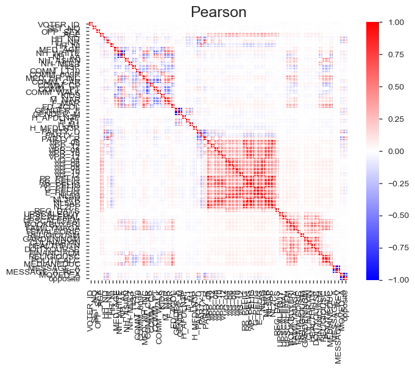

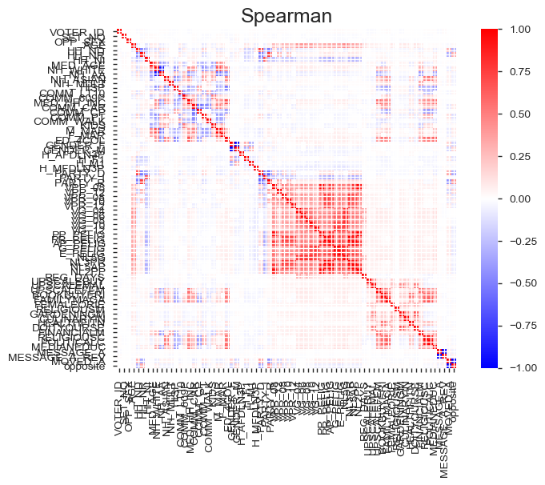

# Sample

|  | VOTER_ID | SET_NO | OPP_SEX | AGE | HH_ND | HH_NR | HH_NI | MED_AGE | NH_WHITE | NH_AA | NH_ASIAN | NH_MULT | HISP | COMM_LT10 | COMM_609P | MED_HH_INC | COMM_CAR | COMM_CP | COMM_PT | COMM_WALK | KIDS | M_MAR | F_MAR | ED_4COL | GENDER_F | GENDER_M | H_AFDLN3P | H_F1 | H_M1 | … |
| --- | --- | --- | --- | --- | --- | --- | --- | --- | --- | --- | --- | --- | --- | --- | --- | --- | --- | --- | --- | --- | --- | --- | --- | --- | --- | --- | --- | --- | --- | --- |
| 0 | 193801 | 2 | 0 | 28 | 1 | 1 | 1 | 37 | 61 | 34 | 0 | 0 | 4 | 26 | 2 | 59954 | 79 | 21 | 0 | 0 | 7 | 20 | 64 | 11 | 1 | 0 | 0 | 0 | 0 | … |
| 1 | 627701 | 1 | 0 | 53 | 2 | 0 | 0 | 46 | 87 | 8 | 0 | 0 | 5 | 10 | 1 | 56196 | 74 | 22 | 1 | 1 | 16 | 61 | 54 | 14 | 0 | 1 | 0 | 0 | 0 | … |
| 2 | 306924 | 2 | 0 | 68 | 2 | 1 | 0 | 41 | 23 | 64 | 7 | 2 | 3 | 5 | 7 | 58950 | 76 | 5 | 11 | 3 | 25 | 50 | 54 | 15 | 1 | 0 | 0 | 0 | 0 | … |
| 3 | 547609 | 1 | 0 | 66 | 0 | 2 | 0 | 35 | 53 | 29 | 4 | 0 | 3 | 27 | 4 | 54809 | 71 | 2 | 2 | 6 | 30 | 35 | 62 | 39 | 0 | 1 | 0 | 0 | 0 | … |
| 4 | 141105 | 3 | 0 | 23 | 0 | 3 | 1 | 42 | 74 | 18 | 0 | 0 | 8 | 6 | 12 | 75063 | 92 | 4 | 2 | 0 | 24 | 50 | 50 | 19 | 0 | 1 | 0 | 0 | 0 | … |